# Práctica 2: Booking Data Cleaning

Gerard Alcalde and Guillem Rochina

2022-12-24

## 1. DESCRIPCIÓN DEL DATASET

### ¿Por qué es importante y qué pregunta/problema pretende responder?

#### 1.1. Descripción general

El conjunto de datos ha tratar es el obtenido como resultado de la práctica anterior de Web Scraping. El dataset presenta los datos e indicadores más relevantes de cada uno de los hoteles encontrados en función de determinados criterios de búsqueda (ciudad, fecha de check-in, fecha de check-out, número de adultos, niños y habitaciones). En este dataset en concreto presentamos datos para distintas fechas (diciembre, marzo y junio), ciudades (barcelona, madrid, valencia), número de adultos, niños y habitaciones a fin de tener una muestra más amplia e informativa que la que nos daría una búsqueda con tan sólo unos parámetros fijos.

A continuación, se realiza una breve descripción de cada una de las variables disponibles antes de realizar la limpieza:

- **Name (str)**: Nombre del hotel.
- **City (str)**: Nombre de la ciudad donde se realiza la búsqueda.
- **Check-in (str)**: Fecha de entrada al hotel.
- **Check-out (str)**: Fecha de salida del hotel.
- **Adults (int)**: Nº de adultos para los que se realiza la reserva.
- **Num_rooms (int)**: Nº de habitaciones reservadas.
- **Address (str)**: Dirección postal del hotel, nombre de calle, barrio de la ciudad, código postal, etc.
- **Hotel_coordinates (str)**: Latitud y longitud de la ubicación del hotel.
- **Hotel_score (int)**: Nota general que recibe el hotel por los usuarios.
- **Hotel_scores (dict)**: Puntuaciones de cada una de las dimensiones que puede valorar un usuario.
- **Hotel description (list)**: Descripción aportada por el propietario del hotel
- **Features (list)**: Lista de servicios añadidos del hotel.
- **Room_data (dict)**: Conjunto de diccionarios que recogen las características de cada una de las habitaciones disponibles en el hotel.
- **Page_count (int)**: Posición en la que ha aparecido el hotel en el buscador.
- **Current_page (int)**: Página en la que ha aparecido el hotel en el buscador.

#### 1.2. Importancia y problema a responder

Aparecer en los primeros resultados de una búsqueda de un usuario por internet se ha convertido en los últimos años en una de las preocupaciones principales de cualquier negocio que busca hacerse un hueco en el mundo digital. Este fenómeno explica la proliferación de herramientas como el SEO y el SEM, mediante las cuales se intenta innovar (más allá del pago de tarifas para aparecer en las primeras páginas de búsqueda) a fin de lograr un mejor “posicionamiento” en buscadores como Google o Bing. El negocio hotelero no es una excepción en este caso. No obstante, el uso de dichas herramientas no resulta útil si nos enfrentamos a un buscador dentro de una página web, como el caso que nos ocupa con Booking.com. ¿Qué hacer entonces? ¿Cómo mejorar el posicionamiento dentro de la web? Asimismo, la fijación de precios o “pricing” puede ser una tardea ardua en los últimos años, pues la aparición de apartamentos vacacionales a través de plataformas como AirBnB ha incrementado de manera significativa la competencia a la que se deben enfrentar los propietarios de los hoteles, lo que influye en última instancia los precios a establecer por sus servicios. Dicho esto, ¿Qué precios se deben fijar dadas las características de un hotel? ¿Añadir un servicio adicional permitiría a un hotel elevar los precios de sus habitaciones?. Ante las preguntas presentadas en los párrafos anteriores, el objetivo de este proyecto es dual. Por un lado se busca obtener las características que hacen que un hotel esté mejor posicionado que otro en el metabuscador de Booking.com y, por el otro, se persigue desarrollar un modelo que indique qué precios se deberían establecer dadas las características de una habitación y qué elementos pueden incrementar el precio de forma relevante. En conclusión, el presente proyecto pretende dar continuidad a la Práctica 1, explotando los datos que se obtuvieron mediante web scrapping para ayudar a superar dos de los desafíos más relevantes para el sector hotelero.

## 2. LIMPIEZA DE LOS DATOS

Dado que muchas de las variables que desecharemos en la sección de selección e integración las vamos a utilizar en a continuación, procedemos a realizar previamente la limpieza de los datos. A fin de iniciar el proceso, en primer lugar, se debe realizar la lectura del fichero csv que obtuvimos en la práctica anterior. Como resultado de la función de R-base “read.csv” obtenemos un objeto data.frame, que manipularemos en la presente sección.

```r
# Lectura y breve descripción de los datos

booking <- read.csv("../data/hotels_data.csv", header = TRUE)
summary(booking)
```

```
##      name               city             check.in             adults
##  Length:3912        Length:3912        Length:3912        Min.   :2.000
##  Class :character   Class :character   Class :character   1st Qu.:2.000
##  Mode  :character   Mode  :character   Mode  :character   Median :4.000
##                                                           Mean   :3.329
##                                                           3rd Qu.:5.000
##                                                           Max.   :5.000
##
##     children      check.out           num_rooms       address
##  Min.   :1.000   Length:3912        Min.   :2.000   Length:3912
##  1st Qu.:1.000   Class :character   1st Qu.:2.000   Class :character
##  Median :3.000   Mode  :character   Median :2.000   Mode  :character
##  Mean   :2.475                      Mean   :2.268
##  3rd Qu.:3.000                      3rd Qu.:3.000
##  Max.   :3.000                      Max.   :3.000
##
##  hotel_coordinates   hotel_score     hotel_scores       hotel_description
##  Length:3912        Min.   :-1.000   Length:3912        Length:3912
##  Class :character   1st Qu.: 8.000   Class :character   Class :character
##  Mode  :character   Median : 8.400   Mode  :character   Mode  :character
##                     Mean   : 8.259
##                     3rd Qu.: 8.800
##                     Max.   :10.000
##                     NA's   :8
##    features          room_data           page_count      current_page
##  Length:3912        Length:3912        Min.   :  0.00   Min.   :1.000
##  Class :character   Class :character   1st Qu.: 24.00   1st Qu.:1.000
##  Mode  :character   Mode  :character   Median : 53.00   Median :3.000
##                                        Mean   : 57.19   Mean   :2.741
##                                        3rd Qu.: 88.00   3rd Qu.:4.000
##                                        Max.   :133.00   Max.   :5.000
##
##  in_page_count   search_date
##  Min.   : 0.00   Length:3912
##  1st Qu.: 6.00   Class :character
##  Median :13.00   Mode  :character
##  Mean   :12.66
##  3rd Qu.:19.00
##  Max.   :27.00
##
```

```r
# Tipo de dato asignado a cada variable

res <- sapply(booking, function(x) class(x))
kable(data.frame(var=names(res), clase=as.vector(res)))
```

| var | clase |
| --- | --- |
| name | character |
| city | character |
| check.in | character |
| adults | integer |
| children | integer |
| check.out | character |
| num_rooms | integer |
| address | character |
| hotel_coordinates | character |
| hotel_score | numeric |
| hotel_scores | character |
| hotel_description | character |
| features | character |
| room_data | character |
| page_count | integer |
| current_page | integer |
| in_page_count | integer |
| search_date | character |

#### 2.1. Transformación de las variables en el formato adecuado

Como se ha comentado, existen algunas variables que presentan todavía una estructura no válida para tratarlos estadísticamente o introducirlos en un modelo de data mining. En esta sección nos encargamos de tratar dichas columnas a fin de obtener nuevas variables con un formato adecuado, eliminando a su vez cualquier información que no nos sea de utilidad.

La columna hotel_coordinates incluye tanto los valores de latitud como los de longitud, separados por una coma. Dado que ambos dos valores nos indican información distinta, pues la latitud nos proporcionar información de la posición en dirección norte o sur del ecuador y la longitud información de la posición en dirección este u oeste, en este caso hemos optado por separarlos en dos columnas distintas.

```r
# Separamos los valores de la variable hotel coordinates en dos nuevas columnas, latitud y longitud
# La columna hotel_coordinates se elimina en el proceso

booking <- booking %>%
  separate(hotel_coordinates, c("latitude", "longitude"), sep = ",", remove = FALSE)
booking$latitude <- as.numeric(booking$latitude)
booking$longitude <- as.numeric(booking$longitude)
```

Por su parte, hotel_scores alberga un diccionario en cada uno de los registros. Cada diccionario consta del nombre de cada dimensión (característica a valorar) como clave y la valoración que recibe como valor. Dado que R lo ha interpretado como un string, nuestro enfoque en su limpieza se ha basado en separar la información en base a las comas como separador y, una vez obtenidas todas las columnas resultantes, extraer los datos numéricos de cada registro para quedarnos solo con los scores de cada dimensión con la función “parse_numbers”.

```r
# Definimos un vector con los nombres de las columnas a crear

columns <-  c("staff_score", "facilities_score", "cleanliness_score", "comfort_score", "value_for_money_score", "location_score", "free_wifi_score")

# Separamos los strings (diccionarios) en función de las comas y creamos las columnas correspondientes. La primera columna creada es una NA porque todos los primeros registros en cada diccionario están vacíos (por un fallo en la extracción de datos). Estableciendo la columna como NA, indicamos a la función separate que ignore dichos datos y no cree columna alguna para ellos.

booking <- booking %>%
  separate(hotel_scores, c(NA, "staff_score", "facilities_score", "cleanliness_score", "comfort_score", "value_for_money_score", "location_score", "free_wifi_score"), sep = ",", remove = FALSE)
# Extraemos los valores numéricos de cada columna con la función del paquete readr, "parse_number"

booking[columns] <- apply(booking[columns], 2, readr::parse_number)
```

Dado que de las fechas tan sólo nos interesa el mes en el que se realiza la reserva (un alojamiento con unas características determinadas podría estar mejor posicionado en un determinado mes que en otro o tener un precio distinto) procedemos a extraer dicha información de las variables check-in y check-out. De hecho, dado que los datos que hemos extraído corresponden al mismo mes en todos los registros, tan sólo nos quedaremos con una columna de mes. Asimismo, no crearemos una columna is_june, pues la dejaremos como caso base, es decir, cuando no sea ninguna de las otras dos opciones (o Diciembre o Marzo).

```r
booking <- booking %>%
  # Separamos el nombre del mes del resto de elementos del registro para check_in y check_out. Eliminamos las columnas en el proceso.
  separate(check.in, c(NA, "month", NA), sep = "-", remove = FALSE) %>%
  mutate(is_december = ifelse(month == "December", 1, 0),
         is_march = ifelse(month == "March", 1, 0))
```

De la columna address tan sólo nos interesa el código postal (el barrio no se incluye en todos los registros a diferencia del CP, así que hemos optado por quedarnos con estos valores), por lo que extraemos dicha información para crear una nueva columna llamada postal_code.

```r
# Hemos tenido que cambiar esta función para que el extract no diera problemas
Sys.setlocale('LC_ALL', 'C')
```

```
## [1] "C"
```

```r
# Extraemos los valores de codigo postal de la columna addres utilizando expressiones regulares
booking <- booking %>%
  extract(address, c("postal_code"), regex = "( [0-9]{5} )", remove = FALSE)
```

Los features, entendidos como servicios adicionales más allá de la propia habitación, fueron guardados como una lista. No obstante, de nuevo nos encontramos como R lo ha identificado como string. Es por ello por lo que realizamos un tratamiento similar al de la columna de scores. En este caso creamos tantas variables dummy (columnas dicotómicas con valores de 1, en caso de que el feature exista en dicho registro, o 0, en caso de que no exista) como servicios adicionales de hotel consideramos interesantes.

```r
# Definimos las features que consideramos que son interesantes. Utilizamos este formato para filtrar por expresión regular.
feature_list <- c("('Free WiFi')", "('Air conditioning')", "('24-hour front desk')", "('Safe')", "('Heating')", "('Elevator')", "('Private Bathroom')", "('Non-smoking rooms')", "('Aparments')", "('City view')","('Kitchen')", "('Pet friendly')", "('Swimming pool')", "('Balcony')")

# Creamos un bucle en el que se recorre cada elemento de la lista de features
for (feature in feature_list){
  # Se eliminan los parentésis y comillas de la variable local feature para crear el nombre de la columna.
  col_name <- str_replace(str_replace(str_to_lower(str_extract(feature, "([A-Z][a-z]*( |-)?[A-Z]?[a-z]* ? ?[A-Z]?[a-z]*)")), " ", "_"), "-", "_")
  booking <- booking %>%
  # Extraemos el nombre del feature de cada uno de los registros (strings). En caso de que no encuentre ningún valor devuelve un NA.
  extract(features, c(col_name), regex = feature, remove = FALSE) %>%
  # Transformamos la columna que acaba de ser creada para que indique con un 1 si el registro tenia dicho servicio y 0 si el valor era NA (no tenida dicho servicio)
  mutate_(.dots = setNames(list(paste0("as.integer(!is.na(",col_name,"))")), col_name))
}
```

Por otro lado, nos encontramos con la columna que incluye la descripción del hotel, esta descripción es muy amplia y un análisis profundo de ella requeriría de técnicas de NLP, las cuales no son el objetivo de esta práctica. No obstante, consideramos que la longitud de la descripción del hotel sí que puede tener una relación con la posición en el buscador, por lo que transformaremos esta variable a una nueva variable que contenga el número total de palabras que contiene la descripción.

```r
# Evaluamos la longitud de la descripción del hotel
booking$length_description <- lengths(gregexpr("\\W+", booking$hotel_description)) + 1
```

Finalmente, en la columna room_data, se incluye mucha información referente a los tipos de habitaciones disponibles, precios, características, etc. Esta se había extraído de esta forma con el objetivo de procesarla mediante un diccionario de Python. No obstante, al haber optado por un procesado con R este se complicará un poco más. En esta columna tenemos distintos datos que pueden ser muy relevantes, de los cuales extraeremos los siguientes: • min_price: Precio de la habitación más económica. • max_price: Precio de las habitaciones más caras del hotel. • suite_available: Una de las habitaciones es de tipo suite. • is_apartment: Una de las habitaciones es de tipo apartamento. • free_cancelation_available: Alguna de las habitaciones tiene cancelación gratuita.

```r
# Función que encuentra el precio mínimo de la habitación dado un string con la información de las habitaciones
find_min_price <- function(text) {
  if (text=="{}"){
    return(NA)
  }
  a <- gregexpr("([0-9]*', 'room_capacity)", text)

  min_price <- NA
  for (value in a[[1]]){
    substring <- substr(text, value, value+20)
    price <- as.numeric(strsplit(substring, "'")[[1]][1])
    if (is.na(min_price)) {
      min_price <- price
    }

    if (price < min_price) {
      min_price <- price
    }
  }
  if (min_price == 0){
    return(NA)
  }
  else {
    return(min_price)
  }
}

# Aplicamos la función a todos los valores
min_price_vector <- c()
for (i in seq(1, length(booking$room_data))) {
  min_price_vector <- append(min_price_vector, find_min_price(booking$room_data[i]))
}

# Guardamos los resultados en una nueva columna.
booking$min_price <- min_price_vector

# Función que encuentra el precio máximo de la habitación dado un string con la información de las habitaciones
find_max_price <- function(text) {
  if (text=="{}"){
    return(NA)
  }
  a <- gregexpr("([0-9]*', 'room_capacity)", text)

  max_price <- NA
  for (value in a[[1]]){
    substring <- substr(text, value, value+20)
    price <- as.numeric(strsplit(substring, "'")[[1]][1])
    if (is.na(max_price)) {
      max_price <- price
    }

    if (price > max_price) {
      max_price <- price
    }
  }
  if (max_price == 0){
    return(NA)
  }
  else {
    return(max_price)
  }
}

# Aplicamos la función a todos los valores
max_price_vector <- c()
for (i in seq(1, length(booking$room_data))) {
  max_price_vector <- append(max_price_vector, find_max_price(booking$room_data[i]))
}

# Guardamos los resultados en una nueva columna.
booking$max_price <- max_price_vector

# Buscamos si hay una habitación en suite
is_suite_vector <- c()
for (i in seq(1, length(booking$room_data))) {
  is_suite <- gregexpr("(suite)", booking$room_data[i])[[1]][1]

  if (is_suite==-1) {
    is_suite_vector <- append(is_suite_vector, 0)
  } else {
    is_suite_vector <- append(is_suite_vector, 1)
  }
}

# Guardamos los resultados en una nueva columna.
booking$is_suite <- is_suite_vector

# Buscamos si hay opción de apartamento
is_apartment_vector <- c()
for (i in seq(1, length(booking$room_data))) {
  is_apartment <- gregexpr("(Apartment)", booking$room_data[i])[[1]][1]

  if (is_apartment==-1) {
    is_apartment_vector <- append(is_apartment_vector, 0)
  } else {
    is_apartment_vector <- append(is_apartment_vector, 1)
  }
}

# Guardamos los resultados en una nueva columna.
booking$is_apartment <- is_apartment_vector

# Buscamos si tiene cancelación gratuita
free_cancelation_vector <- c()
for (i in seq(1, length(booking$room_data))) {
  free_cancelation <- gregexpr("(Free cancellation)", booking$room_data[i])[[1]][1]

  if (free_cancelation==-1) {
    free_cancelation_vector <- append(free_cancelation_vector, 0)
  } else {
    free_cancelation_vector <- append(free_cancelation_vector, 1)
  }
}

# Guardamos los resultados en una nueva columna.
booking$has_free_cancelation <- free_cancelation_vector
```

#### 2.2. Ceros y elementos vacíos

Dando paso a el tratamiento de ceros y elementos vacios, lo primero que debemos hacer es identificar aquellas variables en las que encontramos valores faltantes. Como observamos, “postal_code” (19), “longitude” (16), “hotel_score” (8), min (45) y max_price (17) y el resto de variables relacionadas con los scores (60) presentan valores faltantes, destacando free_wifi_score con 423 registros faltantes, consecuencia con toda seguridad de la ausencia de este servicio en dichos hoteles.

```r
# Comprobamos que columnas tienen datos faltantes
kable(sapply(booking, function(y) sum(is.na(y))))
```

|  | x |
| --- | --- |
| name | 0 |
| city | 0 |
| check.in | 0 |
| month | 0 |
| adults | 0 |
| children | 0 |
| check.out | 0 |
| num_rooms | 0 |
| address | 0 |
| postal_code | 19 |
| hotel_coordinates | 0 |
| latitude | 16 |
| longitude | 16 |
| hotel_score | 8 |
| hotel_scores | 0 |
| staff_score | 60 |
| facilities_score | 60 |
| cleanliness_score | 60 |
| comfort_score | 60 |
| value_for_money_score | 60 |
| location_score | 60 |
| free_wifi_score | 423 |
| hotel_description | 0 |
| features | 0 |
| balcony | 0 |
| swimming_pool | 0 |
| pet_friendly | 0 |
| kitchen | 0 |
| city_view | 0 |
| aparments | 0 |
| non_smoking_rooms | 0 |
| private_bathroom | 0 |
| elevator | 0 |
| heating | 0 |
| safe | 0 |
| air_conditioning | 0 |
| free_wifi | 0 |
| room_data | 0 |
| page_count | 0 |
| current_page | 0 |
| in_page_count | 0 |
| search_date | 0 |
| is_december | 0 |
| is_march | 0 |
| as.integer(!is.na(NA)) | 0 |
| length_description | 0 |
| min_price | 45 |
| max_price | 17 |
| is_suite | 0 |
| is_apartment | 0 |
| has_free_cancelation | 0 |

Por lo que respecta a la variable “postal_code” encontramos que en todos aquellos registros donde se encuentan NAs, también hallamos datos faltantes en la mayoría del resto de columnas. Por tanto, dado que dichos registros no nos aportan información de valor, procedemos a eliminarlos del dataset.

```r
# Comprobamos algunos de los registros donde hay datos faltantes de postal_code
kable(booking[is.na(booking$postal_code),] %>%
  dplyr::select(c("city", "month", "postal_code", "longitude", "hotel_score", "staff_score")) %>%
  head(3))
```

|  | city | month | postal_code | longitude | hotel_score | staff_score |
| --- | --- | --- | --- | --- | --- | --- |
| 202 | Barcelona | December | NA | NA | -1 | NA |
| 203 | Barcelona | December | NA | NA | -1 | NA |
| 223 | Barcelona | December | NA | NA | -1 | NA |

```r
# Filtramos los datos para eliminar aquellos registros que tienen NAs en postal_code
booking <- booking[!is.na(booking$postal_code),]
```

```r
# Comprobamos que columnas tienen datos faltantes
kable(sapply(booking, function(y) sum(is.na(y))))
```

|  | x |
| --- | --- |
| name | 0 |
| city | 0 |
| check.in | 0 |
| month | 0 |
| adults | 0 |
| children | 0 |
| check.out | 0 |
| num_rooms | 0 |
| address | 0 |
| postal_code | 0 |
| hotel_coordinates | 0 |
| latitude | 0 |
| longitude | 0 |
| hotel_score | 5 |
| hotel_scores | 0 |
| staff_score | 44 |
| facilities_score | 44 |
| cleanliness_score | 44 |
| comfort_score | 44 |
| value_for_money_score | 44 |
| location_score | 44 |
| free_wifi_score | 407 |
| hotel_description | 0 |
| features | 0 |
| balcony | 0 |
| swimming_pool | 0 |
| pet_friendly | 0 |
| kitchen | 0 |
| city_view | 0 |
| aparments | 0 |
| non_smoking_rooms | 0 |
| private_bathroom | 0 |
| elevator | 0 |
| heating | 0 |
| safe | 0 |
| air_conditioning | 0 |
| free_wifi | 0 |
| room_data | 0 |
| page_count | 0 |
| current_page | 0 |
| in_page_count | 0 |
| search_date | 0 |
| is_december | 0 |
| is_march | 0 |
| as.integer(!is.na(NA)) | 0 |
| length_description | 0 |
| min_price | 29 |
| max_price | 1 |
| is_suite | 0 |
| is_apartment | 0 |
| has_free_cancelation | 0 |

A continuación, analizamos los datos faltantes de hotel_score. En este caso, encontramos que la ausencia de datos se registra de dos formas distintas, o bien con la introducción de NAs o bien con el valor -1. Por tanto, dado que el tratamiento en ambos casos va a ser el mismo, transformamos todos los valores -1 en NAs para poder llevar a cabo el siguiente proceso de inputación.

```r
# Comprobamos algunos de los registros donde hay datos faltantes de hotel_score
booking[is.na(booking$hotel_score),] %>%
  dplyr::select(c("city", "month", "hotel_score", "staff_score", "location_score", "longitude", "facilities_score", "cleanliness_score", "comfort_score")) %>%
  head(5)
```

```
##           city    month hotel_score staff_score location_score  longitude
## 310  Barcelona December          NA         9.4            9.4  2.1787906
## 844   Valencia December          NA         7.7            9.5 -0.3775288
## 958   Valencia December          NA         9.2            9.3 -0.3247243
## 1210 Barcelona    March          NA         8.1            8.6  2.1429321
## 2708 Barcelona     June          NA         8.1            8.6  2.1429321
##      facilities_score cleanliness_score comfort_score
## 310               8.6               8.9           8.9
## 844               7.2               7.5           7.6
## 958               9.1               9.3           9.3
## 1210              7.3               7.7           7.7
## 2708              7.3               7.7           7.7
```

```r
# Comprobamos algunos de los registros donde hay datos faltantes de hotel_score
kable(booking[booking$hotel_score == "-1",] %>%
  dplyr::select(c("city", "month", "hotel_score", "staff_score", "location_score", "longitude", "facilities_score", "cleanliness_score", "comfort_score")) %>%
  tail(5))
```

|  | city | month | hotel_score | staff_score | location_score | longitude | facilities_score | cleanliness_score | comfort_score |
| --- | --- | --- | --- | --- | --- | --- | --- | --- | --- |
| 3690 | Madrid | June | -1 | NA | NA | -3.699663 | NA | NA | NA |
| 3736 | Madrid | March | -1 | NA | NA | -3.709937 | NA | NA | NA |
| 3855 | Madrid | March | -1 | NA | NA | -3.700559 | NA | NA | NA |
| 3877 | Madrid | March | -1 | NA | NA | -3.699663 | NA | NA | NA |
| 3909 | Madrid | March | -1 | NA | NA | -3.699676 | NA | NA | NA |

```r
kable(booking[booking$hotel_score == "-1",] %>%
  dplyr::select(c("city", "month", "hotel_score", "staff_score", "free_wifi_score", "free_wifi")) %>%
  tail(5))
```

|  | city | month | hotel_score | staff_score | free_wifi_score | free_wifi |
| --- | --- | --- | --- | --- | --- | --- |
| 3690 | Madrid | June | -1 | NA | NA | 1 |
| 3736 | Madrid | March | -1 | NA | NA | 0 |
| 3855 | Madrid | March | -1 | NA | NA | 1 |
| 3877 | Madrid | March | -1 | NA | NA | 1 |
| 3909 | Madrid | March | -1 | NA | NA | 1 |

```r
# Tranformamos los valores -1 en NAs para poder llevar a cabo el proceso de inputación correctamente.
booking$hotel_score <- ifelse(booking$hotel_score == "-1", NA, booking$hotel_score)
```

Dado que en este caso tan sólo encontramos datos faltantes en las columnas de score, no consideramos eliminar estos registros, sino llevar a cabo una imputación. Aunque se podría haber utilizado una metología más simple como el uso de la media o la mediana, hemos optado por hacer uso de un método más complejo, basado en la similitud entre registros, es decir, una imputación mediante el algoritmo de K vecinos más próximos. En este caso, la función se encarga de devolver los mismos valores en caso de que ya existan en el dataset y el valor de los registros más “similares” en el caso de un registro con NAs.

```r
# Imputamos los datos con K Neirest Neighbours
booking$hotel_score <- kNN(booking)$hotel_score
booking$staff_score <- kNN(booking)$staff_score
booking$facilities_score <- kNN(booking)$facilities_score
booking$cleanliness_score <- kNN(booking)$cleanliness_score
booking$comfort_score <- kNN(booking)$comfort_score
booking$value_for_money_score <- kNN(booking)$value_for_money_score
booking$location_score <- kNN(booking)$location_score
booking$free_wifi_score <- kNN(booking)$free_wifi_score
```

En el caso de los precios, encontramos NAs en aquellos registros que presentaban valores iguales a 0 (no son valores lógicos). En este caso también encontramos que los únicos valores faltantes en estos registros corresponde a precio, por lo que procedemos de la misma forma que con los scores.

```r
kable(booking[is.na(booking$min_price),] %>%
  dplyr::select(c("city", "month", "hotel_score", "max_price", "min_price")) %>%
  tail(5))
```

|  | city | month | hotel_score | max_price | min_price |
| --- | --- | --- | --- | --- | --- |
| 3620 | Madrid | June | 9.5 | 903 | NA |
| 3698 | Madrid | June | 8.2 | 964 | NA |
| 3846 | Madrid | March | 8.8 | 981 | NA |
| 3847 | Madrid | March | 8.6 | 960 | NA |
| 3849 | Madrid | March | 8.9 | 988 | NA |

```r
# Imputamos los datos con K Neirest Neighbours
booking$max_price <- kNN(booking)$max_price
booking$min_price <- kNN(booking)$min_price
```

Una última comprobación nos revela que el dataset ya no cuenta con datos faltantes, con independencia del formato que pudieran presentar (strings vacías, valores de -1 en integers, o simplemente NAs).

```r
# Comprobamos que columnas tienen datos faltantes (si los hay)
kable(sapply(booking, function(y) sum(is.na(y))))
```

|  | x |
| --- | --- |
| name | 0 |
| city | 0 |
| check.in | 0 |
| month | 0 |
| adults | 0 |
| children | 0 |
| check.out | 0 |
| num_rooms | 0 |
| address | 0 |
| postal_code | 0 |
| hotel_coordinates | 0 |
| latitude | 0 |
| longitude | 0 |
| hotel_score | 0 |
| hotel_scores | 0 |
| staff_score | 0 |
| facilities_score | 0 |
| cleanliness_score | 0 |
| comfort_score | 0 |
| value_for_money_score | 0 |
| location_score | 0 |
| free_wifi_score | 0 |
| hotel_description | 0 |
| features | 0 |
| balcony | 0 |
| swimming_pool | 0 |
| pet_friendly | 0 |
| kitchen | 0 |
| city_view | 0 |
| aparments | 0 |
| non_smoking_rooms | 0 |
| private_bathroom | 0 |
| elevator | 0 |
| heating | 0 |
| safe | 0 |
| air_conditioning | 0 |
| free_wifi | 0 |
| room_data | 0 |
| page_count | 0 |
| current_page | 0 |
| in_page_count | 0 |
| search_date | 0 |
| is_december | 0 |
| is_march | 0 |
| as.integer(!is.na(NA)) | 0 |
| length_description | 0 |
| min_price | 0 |
| max_price | 0 |
| is_suite | 0 |
| is_apartment | 0 |
| has_free_cancelation | 0 |

```r
#Comprobamos que columnas tienen datos faltantes (si los hay)
kable(sapply(booking, function(y) sum(y == "")))
```

|  | x |
| --- | --- |
| name | 0 |
| city | 0 |
| check.in | 0 |
| month | 0 |
| adults | 0 |
| children | 0 |
| check.out | 0 |
| num_rooms | 0 |
| address | 0 |
| postal_code | 0 |
| hotel_coordinates | 0 |
| latitude | 0 |
| longitude | 0 |
| hotel_score | 0 |
| hotel_scores | 0 |
| staff_score | 0 |
| facilities_score | 0 |
| cleanliness_score | 0 |
| comfort_score | 0 |
| value_for_money_score | 0 |
| location_score | 0 |
| free_wifi_score | 0 |
| hotel_description | 0 |
| features | 0 |
| balcony | 0 |
| swimming_pool | 0 |
| pet_friendly | 0 |
| kitchen | 0 |
| city_view | 0 |
| aparments | 0 |
| non_smoking_rooms | 0 |
| private_bathroom | 0 |
| elevator | 0 |
| heating | 0 |
| safe | 0 |
| air_conditioning | 0 |
| free_wifi | 0 |
| room_data | 0 |
| page_count | 0 |
| current_page | 0 |
| in_page_count | 0 |
| search_date | 0 |
| is_december | 0 |
| is_march | 0 |
| as.integer(!is.na(NA)) | 0 |
| length_description | 0 |
| min_price | 0 |
| max_price | 0 |
| is_suite | 0 |
| is_apartment | 0 |
| has_free_cancelation | 0 |

#### 2.3. Valores extremos

Los outliers son aquellos datos extremos que, dada su distancia con respecto al grueso de la distribución, a priori resultan no ser congruentes si los comparamos con la población/muestra analizada. Existen varias vías para detectarlos, no obstante el método más rápdio y común se basa en el uso de boxplots. Asimismo, en este trabajo también haremos uso de la función “boxplots.stats()” a fin de detectar, con un output más allá del visual, los outliers que encontramos usando boxplots. Dado que muchas de las variables que hemos generado en la fase de limpieza son dicotómicas, tan solo nos encargaremos de comprobar si existen valores extremos en las columnas de **num_rooms**, **latitude**, **longitude**, **hotel_score** y el resto de **scores del hotel**, **length_description**, **min_price** y **max_price**.

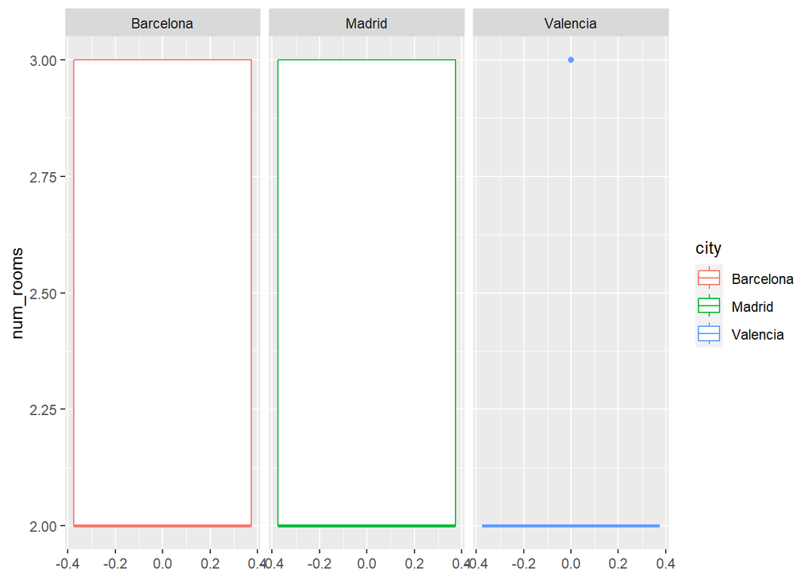

```r
# Graficamos box-plot con ggplot
ggplot(booking, aes(y = num_rooms, color = city))+
  geom_boxplot() +
  facet_grid(~city)
```

```r
# Sacamos los valores considerados outliers
boxplot.stats(booking$num_rooms)$out
```

```
## integer(0)
```

Empezamos analizando el número de habitaciones y observamos que en las 3 ciudades el número oscila entre 2 y 3 habitaciones para las búsquedas realizadas, lo cual son números razonables, aunque en Valencia esta aparezca como un outlier. Por lo tanto, aceptamos los valores outliers observados en la ciudad de Valencia como valores correctos.

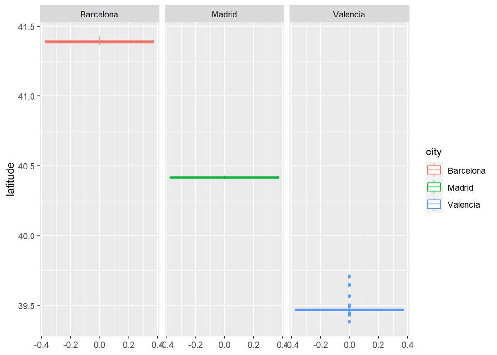

```r
# Graficamos box-plot con ggplot
ggplot(booking, aes(y = latitude, color = city))+
  geom_boxplot() +
  facet_grid(~city)
```

```r
# Sacamos los valores considerados outliers
boxplot.stats(booking$latitude)$out
```

```
## numeric(0)
```

Observamos que la latitud contiene valores distintos para cada ciudad, como es de esperar al tener cada una una ubicación distinta. En el caso de Valencia vemos una mayor dispersión y tenemos la presencia de algunos outliers, esto es debido a que probablemente, al ser una ciudad más pequeña que Madrid o Barcelona tenga una menor disponibilidad hotelera y algunos de los hoteles hayados no pertenezcan a Valencia ciudad sino a los alrededores de esta.

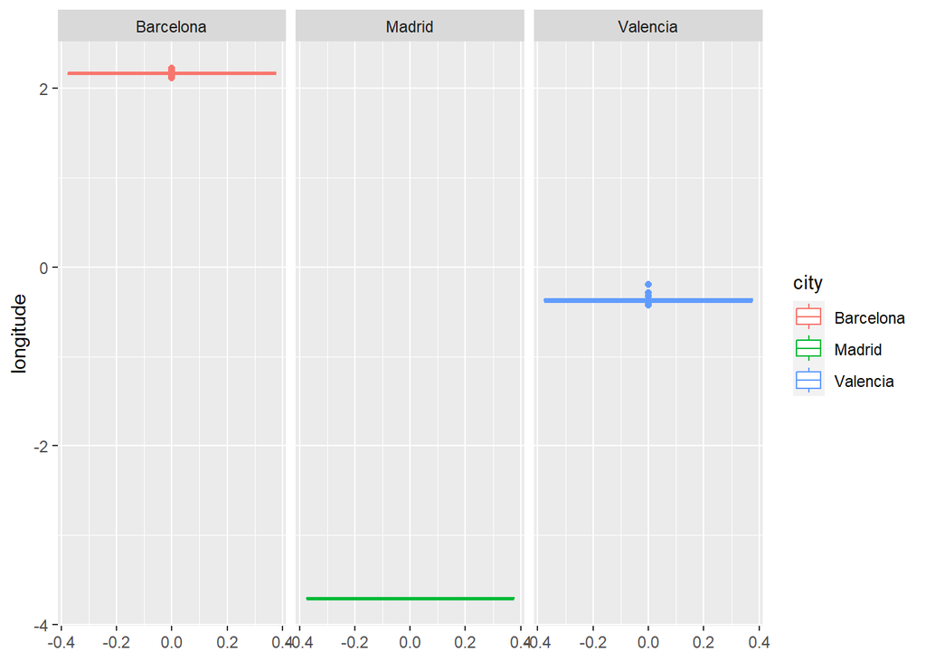

```r
# Graficamos box-plot con ggplot
ggplot(booking, aes(y = longitude, color = city))+
  geom_boxplot() +
  facet_grid(~city)
```

```r
# Sacamos los valores considerados outliers
boxplot.stats(booking$longitude)$out
```

```
## numeric(0)
```

Para la longitud obtenemos unos resultados parecidos, pues hay una menor dispersión en los outliers de Valencia. Dado que estas variaciones tan pequeñas en los resultados son razonables, aceptamos los resultados como validos.

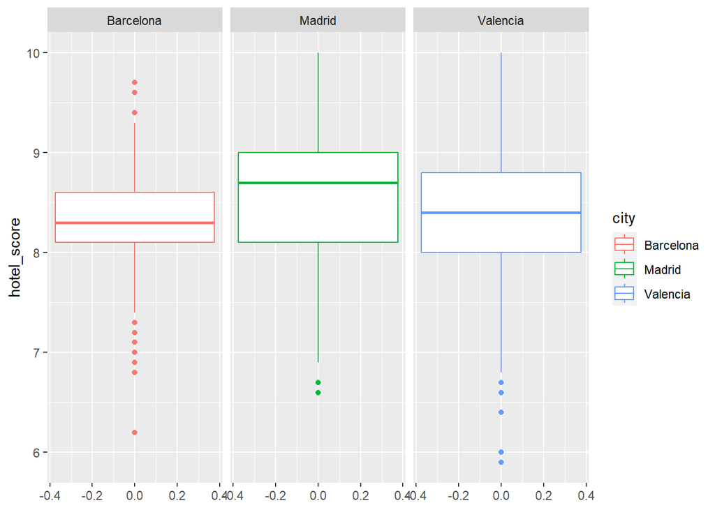

```r
# Graficamos box-plot con ggplot
ggplot(booking, aes(y = hotel_score, color = city))+
  geom_boxplot() +
  facet_grid(~city)
```

```r
# Sacamos los valores considerados outliers
boxplot.stats(booking$hotel_score)$out
```

```
##  [1]  6.9  6.9  6.9  6.9  6.9 10.0  6.6  6.6  5.9  7.0  6.6  6.0  6.6  5.9  6.7
## [16] 10.0  5.9  7.0  6.8  6.6  6.7  6.9  6.0  6.9  6.4 10.0  6.6  6.6 10.0  7.0
## [31]  6.9  6.9  6.9 10.0  7.0  6.6  7.0  6.6  6.7  7.0  6.4  7.0  6.9  6.8 10.0
## [46]  6.9  6.9  7.0  6.2  6.8  7.0  6.6  6.7  7.0  6.9  6.9  6.9  6.9  7.0  7.0
## [61]  6.9  6.9  7.0  5.9  6.0  7.0  6.9  7.0  6.8  6.8  5.9  7.0 10.0  6.6  6.6
## [76]  6.6  7.0  6.9 10.0  6.6 10.0 10.0  6.6
```

En cuanto hotel_score, por un lado observamos que la puntuación general del hotel oscila entre el 8 y el 9 siendo mayor en Madrid que en Barcelona o Valencia. También nos encontramos que hay outliers en las 3 ciudades no obstante todos se hayan en una puntuación entre el 5 y el 10, cuando el rango factible es entre 0 y 10, por lo que pueden ser valores anómalos de hoteles que han obtenido una puntuación más baja de lo normal, pero no por ello deben ser descartados. El análisis de esta variable ser presenta a modo de demostración general:

```r
# Seleccionamos muestras de habitaciones con nota menor a 7
kable(booking %>%
  filter(hotel_score <= 7.0) %>%
  dplyr::select(c("hotel_score", "facilities_score", "cleanliness_score", "location_score")) %>%
  sample_n(5))
```

| hotel_score | facilities_score | cleanliness_score | location_score |
| --- | --- | --- | --- |
| 7.0 | 6.7 | 7.1 | 9.0 |
| 7.0 | 7.1 | 6.8 | 9.1 |
| 7.0 | 7.1 | 6.8 | 9.1 |
| 6.9 | 6.8 | 7.5 | 8.2 |
| 6.9 | 6.5 | 7.6 | 9.3 |

Analizando el resto de scores, se observa que los hoteles con una mala puntuación lo hacen en la mayoría de sus características, lo que corrobora los resultados obtenidos.

```r
# Seleccionamos muestras de habitaciones con nota de 10
kable(booking %>%
  filter(hotel_score == 10.0) %>%
  dplyr::select(c("hotel_score", "facilities_score", "cleanliness_score", "location_score")) %>%
  sample_n(3))
```

| hotel_score | facilities_score | cleanliness_score | location_score |
| --- | --- | --- | --- |
| 10 | 10 | 10 | 10 |
| 10 | 10 | 10 | 10 |
| 10 | 10 | 10 | 10 |

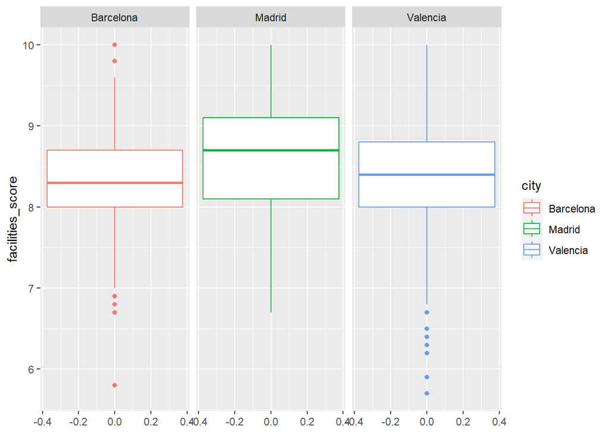

```r
# Graficamos box-plot con ggplot
ggplot(booking, aes(y = facilities_score, color = city))+
  geom_boxplot() +
  facet_grid(~city)
```

```r
# Sacamos los valores considerados outliers
boxplot.stats(booking$facilities_score)$out
```

```
##  [1] 5.9 6.5 5.7 6.4 5.9 5.9 6.5 6.4 6.3 5.9 6.2 6.5 6.5 5.8 6.5 5.9 5.7 6.5 6.5
## [20] 5.9
```

Vemos que los resultados obtenidos continuan en la línea anterior con algunos outliers en Barcelona o Valencia, pero con resultados lógicos.

A continuación evaluamos aquellos hoteles que han obtenido una nota inferior al 6.5 para identificar si se trata de un error o no.

```r
# Seleccionamos una muestra de hoteles con facilities_score menor a 6.5
kable(booking %>%
  filter(facilities_score <= 6.5) %>%
  dplyr::select(c("hotel_score", "facilities_score", "cleanliness_score", "location_score")) %>%
  sample_n(3))
```

| hotel_score | facilities_score | cleanliness_score | location_score |
| --- | --- | --- | --- |
| 6.6 | 6.5 | 7.0 | 8.9 |
| 6.9 | 6.5 | 7.6 | 9.3 |
| 6.0 | 5.7 | 6.4 | 8.9 |

Observamos que los hoteles parecen tener unas características consistentes y que la extracción de características ha sido correcta por lo que no podemos atribuir los resultados a un error sino meramente a una baja calidad del hotel.

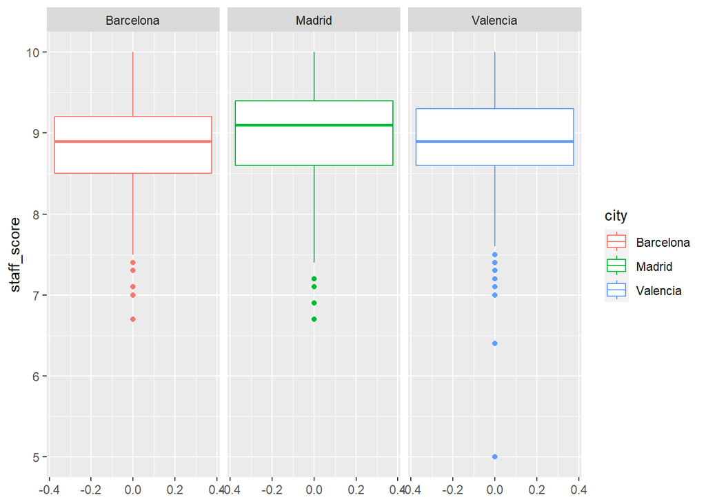

```r
# Graficamos box-plot con ggplot
ggplot(booking, aes(y = staff_score, color = city))+
  geom_boxplot() +
  facet_grid(~city)
```

```r
# Sacamos los valores considerados outliers
boxplot.stats(booking$staff_score)$out
```

```
##   [1] 7.0 7.5 7.4 7.4 7.5 7.4 7.5 7.5 7.5 7.5 6.7 7.5 7.1 7.3 7.3 6.4 7.1 7.2
##  [19] 7.1 7.4 7.4 7.5 7.0 7.4 7.1 7.3 7.2 7.4 7.5 7.5 7.5 6.7 7.4 7.5 7.2 7.1
##  [37] 6.9 7.5 7.4 7.5 7.5 7.5 7.4 7.4 5.0 5.0 7.3 7.3 7.2 7.5 7.1 7.4 7.2 7.3
##  [55] 7.3 7.4 7.3 7.1 5.0 7.3 7.4 7.5 7.0 7.5 7.3 7.4 7.4 7.1 6.7 7.5 7.4 7.5
##  [73] 7.4 7.5 6.7 7.5 7.5 7.4 7.4 7.1 7.5 7.5 7.4 7.5 7.5 7.5 7.4 7.2 7.3 7.5
##  [91] 7.5 7.4 6.7 7.5 7.4 7.4 7.5 7.3 7.3 7.1 6.4 7.3 7.3 7.3 7.3 7.1 7.3 7.5
## [109] 7.5 6.7 7.5 7.5 7.4 7.5 7.5 7.1 7.4 6.9 7.4 7.5 7.4 6.7 7.4 7.5 6.7 7.4
## [127] 7.1 7.5 7.5 7.5 7.2
```

Para la puntuación otorgada a los trabajadores del hotel obtenemos unos resultados similares a los previos, con la diferencia de que en este apartado la puntuación promedio es más elevada rondando el 9 en las 3 ciudades y todas presentan outliers con valores inferiores.

Evaluamos aquellos resultados con puntuaciones muy bajas.

```r
# Seleccionamos una muestra de hoteles con staff_score menor a 6.7
kable(booking %>%
  filter(staff_score <= 6.7) %>%
  dplyr::select(c("hotel_score", "facilities_score", "staff_score", "location_score")) %>%
  sample_n(3))
```

| hotel_score | facilities_score | staff_score | location_score |
| --- | --- | --- | --- |
| 7.3 | 7 | 6.7 | 9.4 |
| 9.0 | 10 | 5.0 | 7.5 |
| 7.3 | 7 | 6.7 | 9.4 |

De los resultados obtenidos sorprende uno en Valencia que tiene unas puntuaciones muy elevadas excepto en **staff_score** la cual es bastante baja. Si nos fijamos estas puntuaciones son muy exactas (10.0, 9.0, 7.5 o 5.0) lo cual puede venir dado por un número de puntuaciones muy reducidas en las que un cliente ha puntuado de forma muy negativa este aspecto. No por ello eliminaremos el registro o lo modificaremos ya que es razonable el resultado, y afectará en la posición que presenta el hotel en el buscador.

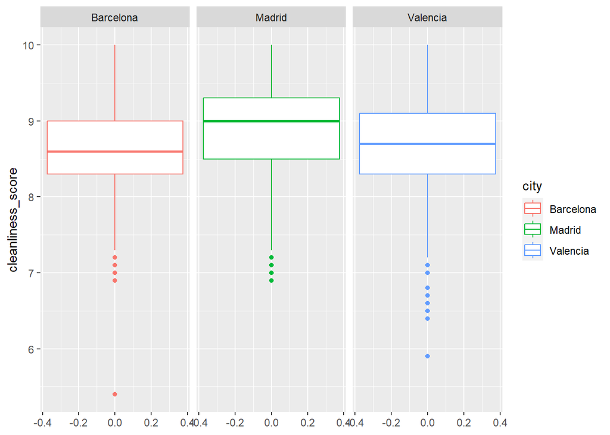

```r
# Graficamos box-plot con ggplot
ggplot(booking, aes(y = cleanliness_score, color = city))+
  geom_boxplot() +
  facet_grid(~city)
```

```r
# Sacamos los valores considerados outliers
boxplot.stats(booking$cleanliness_score)$out
```

```
##  [1] 7.2 6.9 7.2 7.0 7.0 6.9 7.1 5.9 6.8 7.0 7.1 6.4 7.1 5.9 7.2 6.7 7.1 7.1 7.2
## [20] 5.9 6.4 6.7 7.1 6.8 6.6 6.5 7.0 6.9 7.1 7.0 7.1 7.1 7.0 6.9 6.8 7.0 6.7 7.1
## [39] 7.0 6.8 7.0 6.8 7.1 7.1 7.2 7.2 6.9 6.9 5.4 7.1 7.2 7.0 6.9 6.8 7.2 6.5 7.2
## [58] 6.9 6.8 5.9 6.4 6.8 6.5 7.1 6.8 6.7 7.1 6.4 5.9 6.8 7.2 6.9 6.9 7.0 7.1 7.1
## [77] 7.0 7.0 7.0 7.2 7.1 6.9 6.9 7.0
```

A continuación se evalúa la limpieza del hotel. Observamos unos resultados muy similares a los anteriores. Para descartar algún error observamos aquellos registros con puntuaciones excepcionalmente bajas.

```r
# Seleccionamos una muestra de hoteles con cleanliness_score menor a 7
kable(booking %>%
  filter(cleanliness_score < 7.0) %>%
  dplyr::select(c("hotel_score", "facilities_score", "cleanliness_score", "location_score")) %>%
  sample_n(3))
```

| hotel_score | facilities_score | cleanliness_score | location_score |
| --- | --- | --- | --- |
| 6.8 | 6.5 | 6.7 | 9.6 |
| 7.0 | 7.4 | 6.8 | 6.8 |
| 6.6 | 7.2 | 6.9 | 9.1 |

Vemos un comportamiento razonable en estos hoteles, por lo que, siendo resultados razonables, aceptamos estos valores outliers. Se ha seguido el mismo proceso con todo el resto de scores, alcanzando las mismas conclusiones, por lo que no eliminaremos ningún registro que presenta valores “atípicos” en columnas de scores pues sus valores los consideramos lógicos.

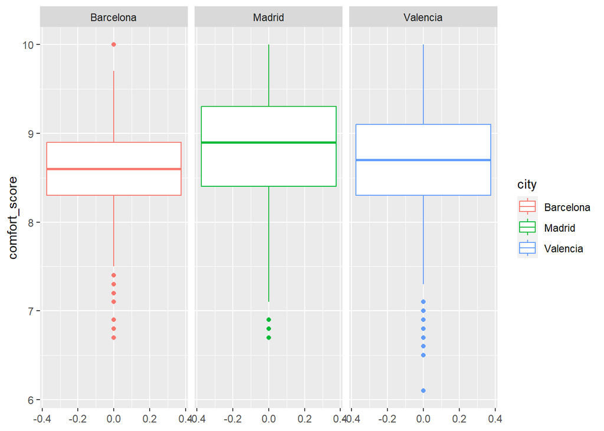

```r
# Graficamos box-plot con ggplot
ggplot(booking, aes(y = comfort_score, color = city))+
  geom_boxplot() +
  facet_grid(~city)
```

```r
# Sacamos los valores considerados outliers
boxplot.stats(booking$comfort_score)$out
```

```
##  [1] 7.1 7.1 7.1 6.8 6.9 7.1 6.7 6.1 7.1 6.8 6.1 6.7 6.1 7.0 7.1 7.1 6.1 7.0 6.7
## [20] 6.7 6.6 6.9 6.5 6.6 6.9 7.1 6.7 7.1 7.1 6.9 6.8 7.1 6.9 6.8 7.0 7.1 7.1 6.8
## [39] 6.7 7.1 6.7 7.1 7.1 6.9 7.1 7.1 7.0 7.1 7.1 7.1 7.1 6.7 7.1 6.1 6.1 7.1 7.0
## [58] 7.1 7.1 6.7 6.7 6.1 6.9 7.1 6.9 6.7 6.8 7.1 6.9 6.9
```

```r
# Seleccionamos una muestra de hoteles con comfort_score menor a 7
kable(booking %>%
  filter(comfort_score < 7.0) %>%
  dplyr::select(c("hotel_score", "facilities_score", "comfort_score", "location_score")) %>%
  sample_n(3))
```

| hotel_score | facilities_score | comfort_score | location_score |
| --- | --- | --- | --- |
| 6.0 | 5.9 | 6.5 | 8.9 |
| 7.2 | 7.2 | 6.9 | 9.3 |
| 6.6 | 7.2 | 6.9 | 9.1 |

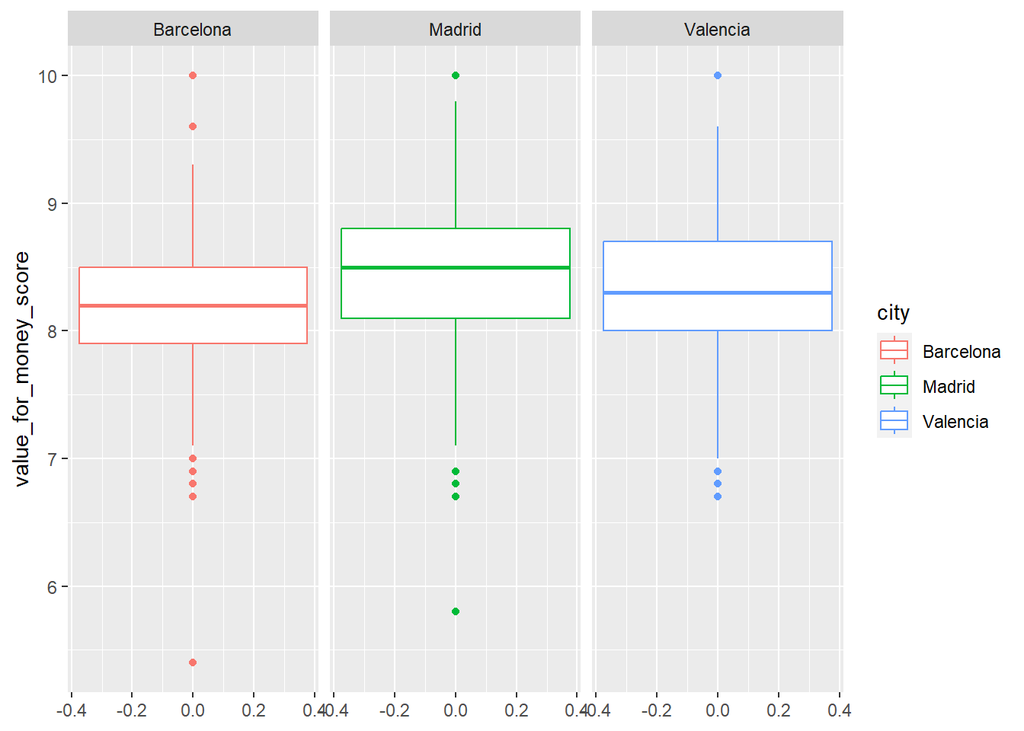

```r
# Graficamos box-plot con ggplot
ggplot(booking, aes(y = value_for_money_score, color = city))+
  geom_boxplot() +
  facet_grid(~city)
```

```r
# Sacamos los valores considerados outliers
boxplot.stats(booking$value_for_money_score)$out
```

```
##  [1]  6.9  6.9 10.0 10.0 10.0  5.8  6.7 10.0  6.7 10.0 10.0  6.7  6.9 10.0  6.7
## [16]  6.8  6.9  6.7  6.7  6.9 10.0 10.0 10.0 10.0  5.8 10.0 10.0  9.8 10.0 10.0
## [31] 10.0  6.8  9.8 10.0 10.0 10.0 10.0 10.0  6.9 10.0  9.8 10.0 10.0  6.7  6.9
## [46] 10.0 10.0  6.9  6.9 10.0  6.7  6.7  5.4  6.9 10.0 10.0  6.8 10.0 10.0 10.0
## [61]  6.9  6.8 10.0 10.0  6.7  6.7  6.7 10.0  6.9  6.7 10.0 10.0 10.0  5.8  6.9
## [76] 10.0 10.0  9.8 10.0 10.0 10.0
```

```r
# Seleccionamos una muestra de hoteles con value_for_money_score menor a 7
kable(booking %>%
  filter(value_for_money_score <= 7.0) %>%
  dplyr::select(c("hotel_score", "facilities_score", "value_for_money_score", "location_score")) %>%
  sample_n(3))
```

| hotel_score | facilities_score | value_for_money_score | location_score |
| --- | --- | --- | --- |
| 6.9 | 6.8 | 7.0 | 8.2 |
| 7.3 | 7.3 | 7.0 | 8.6 |
| 7.1 | 6.7 | 6.7 | 7.2 |

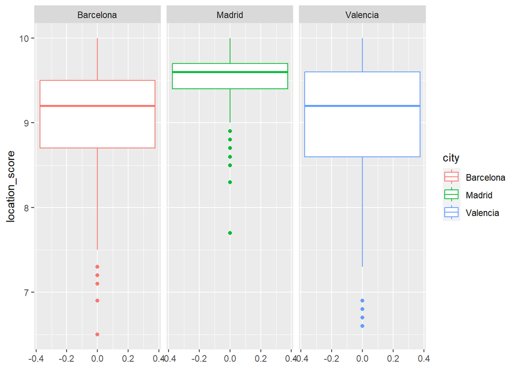

```r
# Graficamos box-plot con ggplot
ggplot(booking, aes(y = location_score, color = city))+
  geom_boxplot() +
  facet_grid(~city)
```

```r
# Sacamos los valores considerados outliers
boxplot.stats(booking$location_score)$out
```

```
##   [1] 7.6 7.3 7.6 7.6 7.2 7.6 6.8 6.7 7.6 7.5 7.7 7.3 7.8 7.6 7.8 7.5 7.8 7.8
##  [19] 7.6 6.8 7.8 6.8 7.8 7.5 7.7 6.6 7.3 7.8 7.5 7.8 7.5 7.8 7.5 7.3 7.6 7.6
##  [37] 7.6 7.7 6.8 7.5 7.5 6.7 7.6 7.6 7.3 7.3 7.5 6.8 6.8 6.8 7.5 7.7 7.7 6.9
##  [55] 7.7 7.8 6.8 7.5 7.8 7.3 7.6 7.5 7.2 7.3 7.8 7.1 7.8 7.2 6.5 6.9 7.6 6.8
##  [73] 7.7 6.8 6.7 7.6 7.6 7.3 7.6 7.6 7.6 7.8 7.5 6.9 7.2 7.2 6.8 7.6 7.8 7.8
##  [91] 6.8 7.7 7.5 7.5 7.8 7.7 7.5 6.8 6.8 6.8 7.8 7.8 7.8 7.7 7.6 7.8 7.7
```

```r
# Seleccionamos una muestra de hoteles con location_score menor a 7
kable(booking %>%
  filter(location_score < 7.0) %>%
  dplyr::select(c("hotel_score", "facilities_score", "value_for_money_score", "location_score")) %>%
  sample_n(3))
```

| hotel_score | facilities_score | value_for_money_score | location_score |
| --- | --- | --- | --- |
| 7.0 | 7.4 | 7.5 | 6.8 |
| 7.9 | 8.0 | 8.1 | 6.8 |
| 7.9 | 8.0 | 8.1 | 6.8 |

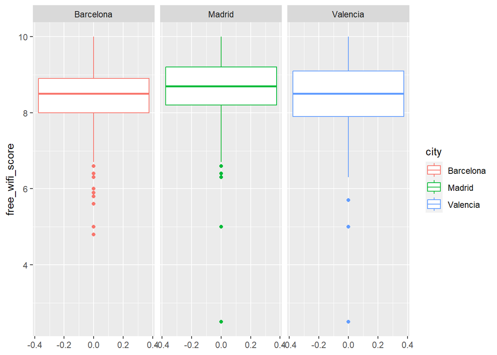

```r
# Graficamos box-plot con ggplot
ggplot(booking, aes(y = free_wifi_score, color = city))+
  geom_boxplot() +
  facet_grid(~city)
```

```r
# Sacamos los valores considerados outliers
boxplot.stats(booking$free_wifi_score)$out
```

```
##   [1] 5.9 5.6 6.6 5.9 5.6 6.4 6.3 6.3 6.6 5.0 6.6 6.5 5.0 5.0 6.5 6.3 5.0 6.5
##  [19] 6.3 2.5 6.7 5.0 6.3 6.6 4.8 5.9 5.6 6.6 5.9 5.6 6.6 4.8 5.0 2.5 6.4 5.9
##  [37] 5.6 6.6 4.8 6.0 5.6 6.4 5.0 6.7 5.0 5.0 5.7 6.4 6.5 5.0 5.0 5.0 5.6 6.4
##  [55] 6.4 6.6 5.0 5.9 6.3 5.6 6.7 5.8 6.6 5.0 6.3 5.0 6.3 5.0 5.9 5.6 6.6 4.8
##  [73] 5.6 5.6 5.9 5.6 4.8 5.9 5.9 6.3 5.9 6.6 6.4 5.9 5.6 5.6 5.8 6.7 5.9 4.8
##  [91] 5.9 5.0 6.6 5.6 5.0 6.3 5.0 5.0 6.5 6.5 5.0 6.5 5.0 5.7 6.5 5.0 6.6 6.6
## [109] 6.3 5.0 6.6
```

```r
# Seleccionamos una muestra de hoteles con free_wifi_score menor a 5
kable(booking %>%
  filter(free_wifi_score < 5.0 & free_wifi_score > 0) %>%
  dplyr::select(c("hotel_score", "facilities_score", "free_wifi_score", "location_score")) %>%
  sample_n(3))
```

| hotel_score | facilities_score | free_wifi_score | location_score |
| --- | --- | --- | --- |
| 8.3 | 8.7 | 2.5 | 8.0 |
| 7.1 | 6.7 | 4.8 | 9.1 |
| 7.1 | 6.7 | 4.8 | 9.1 |

A continuación se evalúa la longitud de las descripciones.

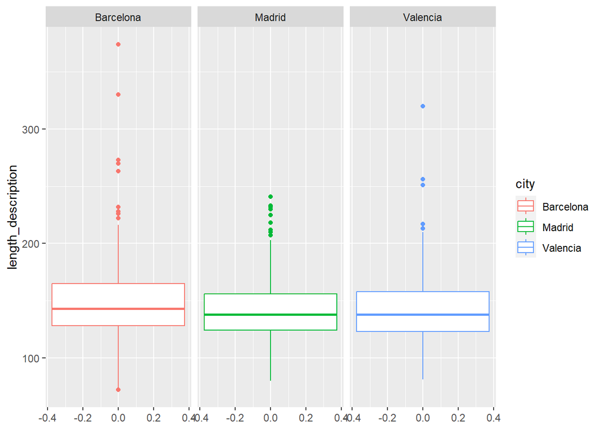

```r
# Graficamos box-plot con ggplot
ggplot(booking, aes(y = length_description, color = city))+
  geom_boxplot() +
  facet_grid(~city)
```

```r
# Sacamos los valores considerados outliers
boxplot.stats(booking$length_description)$out
```

```
##  [1] 226 232 215 270 226 232 270 374 215 226 232 270 330 215 273 228 222 217 213
## [20] 320 251 256 222 226 232  72 216 215 226 218 212 232 225 263 222 233 230 212
## [39] 232 270 330 222 263  73 212 212 218 232 212 241 217 215 226 232 232 228 215
## [58] 330 216 222 226  72 270 232 222 222 222 222 270 222 226 228 330 263  73 251
## [77] 213 320 212 218 230 241 212
```

Observamos que las descripciones tienen una longitud muy similar en las 3 ciudades, en torno a las 120-170 palabras, presentando algún outlier por la parte superior, pero siempre con descripciones inferiores a las 400 palabras. Aunque corresponda a una descripción un poco extensa, no parece que corresponda a un error sino simplemente a una descripción más extensa de lo habitual.

A continuación evaluaremos el precio mínimo de las habitaciones del hotel.

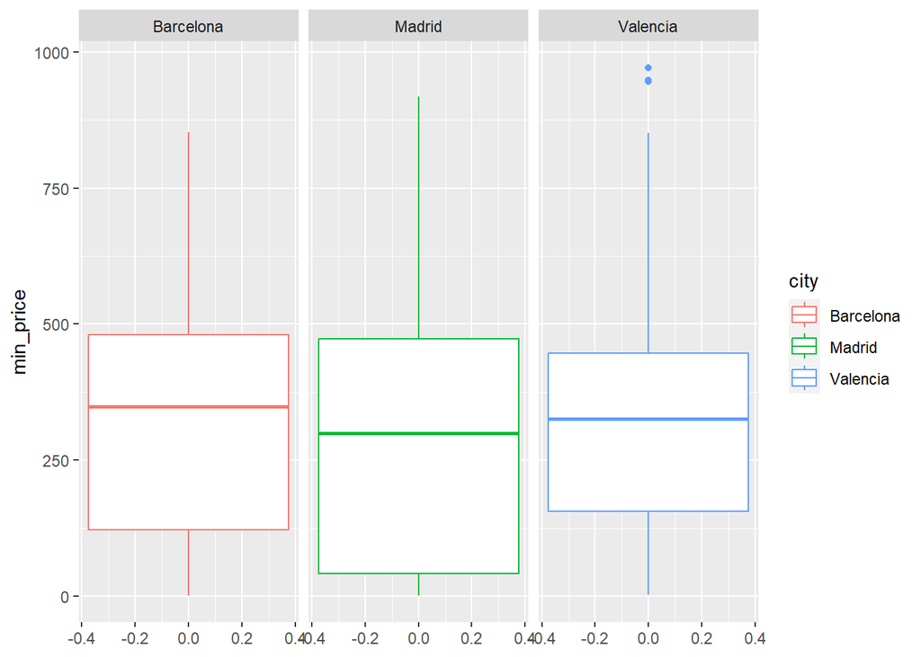

```r
# Graficamos box-plot con ggplot
ggplot(booking, aes(y = min_price, color = city))+
  geom_boxplot() +
  facet_grid(~city)
```

```r
# Sacamos los valores considerados outliers
boxplot.stats(booking$min_price)$out
```

```
## numeric(0)
```

Observamos que el precio mínimo tiene una gran disparidad oscilando de promedio entre los 100€ y los 500€, siendo Valencia la ciudad con el menor rango intercuartil con presencia de outliers en el rango superior de precios, con alguna habitación con precios cercanos a los 1000€, que aunque puedan parecer caros, son razonables en algún hotel de lujo de la ciudad.

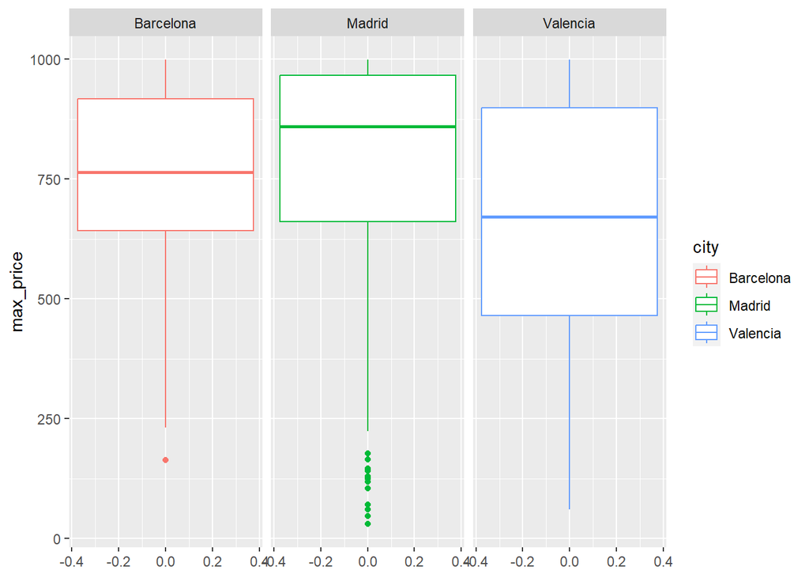

```r
# Graficamos box-plot con ggplot
ggplot(booking, aes(y = max_price, color = city))+
  geom_boxplot() +
  facet_grid(~city)
```

```r
# Sacamos los valores considerados outliers
boxplot.stats(booking$max_price)$out
```

```
## [1] 30 47 30 47
```

A continuación se evalúan los precios máximos. Observamos unos precios promedio mucho más elevados con un mayor rango intercuartílico en la ciudad de Valencia, lo que sorprende al ser lo contrario que con los precios mínimos. También se observa que los outliers en este caso aparecen por el lado inferior especialmente en la ciudad de Madrid, aunque con precios positivos, que podrían corresponder a hoteles muy económicos o albergues.

Por otro lado sorprende ver que los precios máximos no superan el valor máximo observado en el precio mínimo, lo que se puede atribuir a que aquellos hoteles con precios muy elevados no ofrecían una variedad de habitaciones y precios.

## 3. INTEGRACIÓN Y SELECCIÓN

La sección de integración y selección la encontramos tras la de limpieza, pues muchas de las columnas que queriamos descartar han sido tratadas en la fase de limpieza para extraer información de utilidad. Hecho esto, en la presente sección procedemos a eliminar todas las columnas del dataset original que ya no vamos a necesitar para los siguientes apartados.

```r
# Seleccionamos con la función "select" de dplyr todas las columnas excepto las que ya hemos limpiado para crear otras, además de aquellasque nos van a ser de poca utilidad.
booking <- booking %>%
  dplyr::select(-c("name", "search_date", "hotel_coordinates", "hotel_scores", "check.in", "check.out", "address", "features", "hotel_description", "room_data", "as.integer(!is.na(NA))"))
```

Por otro lado, hemos optado por añadir datos de vuelos por varias razones:

- Un mayor número de vuelos en un mes podría aumentar las búsquedas de hoteles cerca del aeropuerto o los precios de dichos alojamientos.
- Un mayor número de vuelos en un mes indica más turismo internacional (en lugar de sólo turismo nacional). Un tipo de turismo que podría estar buscando hoteles con características diferentes a los turistas nacionales.
- Un mayor número de vuelos en un mes indica más turismo general, lo que puede influir en las estrategias de promoción y ofertas de determinados hoteles, influyendo en última instancia en su posición en el buscador Booking y, a su vez, directamente en los precios de los hoteles.

```r
# Leemos los datos de vuelos
flights <- read.csv("../data/avia_tf_apal_linear.csv.gz")
summary(flights)
```

```
##    DATAFLOW         LAST.UPDATE            freq               unit
##  Length:1502955     Length:1502955     Length:1502955     Length:1502955
##  Class :character   Class :character   Class :character   Class :character
##  Mode  :character   Mode  :character   Mode  :character   Mode  :character
##
##
##
##    tra_meas           airline            rep_airp         TIME_PERIOD
##  Length:1502955     Length:1502955     Length:1502955     Length:1502955
##  Class :character   Class :character   Class :character   Class :character
##  Mode  :character   Mode  :character   Mode  :character   Mode  :character
##
##
##
##    OBS_VALUE         OBS_FLAG
##  Min.   :        0   Mode:logical
##  1st Qu.:        0   NA's:1502955
##  Median :      264
##  Mean   :    75333
##  3rd Qu.:     3166
##  Max.   :289204357
```

Para añadir dicha información hacemos un tratamiento de los datos obtenidos en Eurostat a fin de obtener una media de vuelos por mes para los últimos 5 años. Una vez obtenidos, tan solo debemos hacer un merge con nuestro dataset original.

```r
proc_flights <- flights %>%
        # Filtramos para quedarnos solo con los aeropuertos de interés
        # Código OACI/ICAO: Barcelona --> ES_LEBL; Valencia --> ES_LEVC; Madrid: ES_LEMD
        filter(rep_airp %in% c("ES_LEBL", "ES_LEVC", "ES_LEMD")) %>%
        # Filtramos para quedarnos solo con los datos de carga de pasajeros
        filter(tra_meas == "PAS_CRD") %>%
        # Nos interesa solo los datos mensuales, así que filtramos por ellos
        filter(freq == "M") %>%
        separate(TIME_PERIOD, c("YEAR", "MONTH"), sep = "-") %>%
        # Nos quedamos solo con los últimos 5 años y los meses de Marzo, Junio y Diciembre
        filter(YEAR %in% c("2022", "2021", "2020", "2019", "2018") & MONTH %in% c("03", "06", "12")) %>%
        # No nos interesa los datos por aerolínea, solo los generales
        filter(airline == "TOTAL") %>%
        # Modificamos la columna de MONTH para tener los nombres del mes y cambiamos el código del aeropuerto por el nombre de la ciudad
        mutate(month_name = ifelse(MONTH == "03", "March", ifelse(MONTH == "06", "June", "December")),
               city_airp = ifelse(rep_airp == "ES_LEBL", "Barcelona", ifelse(rep_airp == "ES_LEVC", "Valencia", "Madrid"))) %>%
        # Agrupamos por ciudad y mes y calculamos la media de vuelos.
        group_by(rep_airp, month_name) %>%
        mutate(mean_flights = mean(OBS_VALUE)) %>%
        ungroup() %>%
        dplyr::select(c(city_airp, month_name, mean_flights))

# Nos quedamos con los registros únicos
final_flights <- unique(proc_flights)

# Hacemos un merge con bookings
booking <- booking %>%
  merge(final_flights, by.x = c("city", "month"), by.y = c("city_airp", "month_name"))

# Exportamos los datos a un archivo csv
write.csv(booking, "../data/hotel_data_processed.csv", row.names = FALSE)
```

## 4. ANÁLISIS DE LOS DATOS

A continuación, se evaluará la influencia de las distintas variables sobre la posición de un hotel en el buscador y sobre el precio que este fija para sus habitaciones. Para ello se empleará una matriz de correlaciones. Una vez obtenidas las variables con mayor correlación con la variable objetivo generaremos una selección de los atributos a analizar, un grupo de variables distinto por cada problema a tratar.

Tras generar los distintos grupos procederemos a evaluar la normalidad y la homogeneidad de la varianza para así poder determinar en el siguiente punto que pruebas estadísticas se pueden aplicar.

Finalmente aplicaremos distintos tests estadísticos adicionales a la correlación hallada inicialmente. Estas pruebas estadísticas incluirán contrastes de hipótesis y regresiones lineales (enfocados desde un punto de vista inferencial, no predictivo).

#### 4.1 Correlación con la variable objetivo y selección de los grupos de datos que se quieren analizar

Comenzamos evaluando la correlación (de Spearman, dado que no podemos asumir normalidad y utilizamos variables categóricas también) entre las distintas variables con nuestra variable objetivo, para ello creamos varias matrices de correlación y evaluamos los resultados obtenidos.

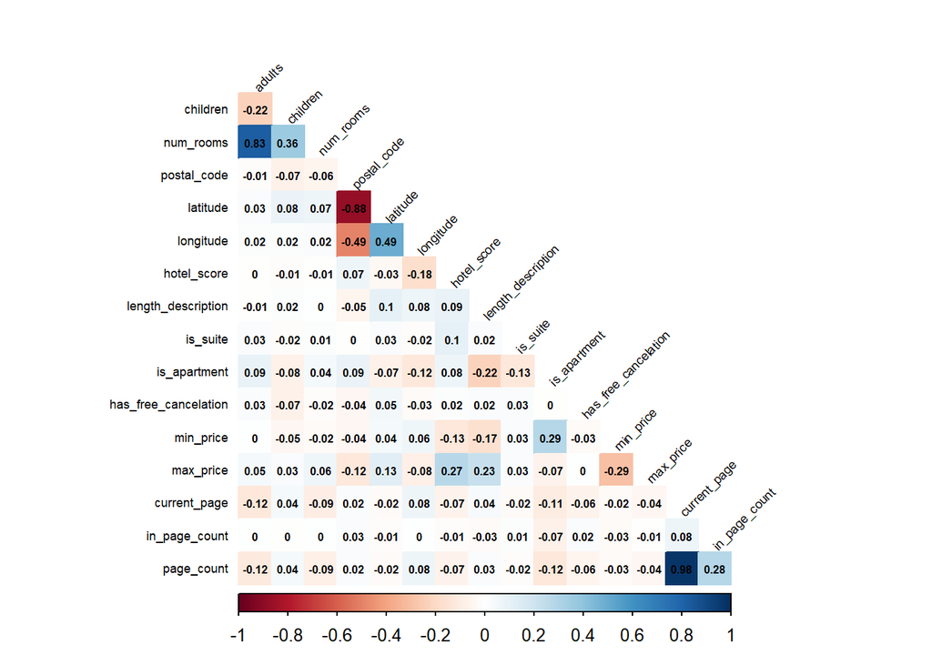

```r
# Transformamos las variables a numérico
booking$postal_code <- as.numeric(booking$postal_code)
booking$latitude <- as.numeric(booking$latitude)
booking$longitude <- as.numeric(booking$longitude)
booking$free_wifi <- as.numeric(booking$free_wifi)
booking$is_apartment <- as.numeric(booking$is_apartment)
booking$pet_friendly <- as.numeric(booking$pet_friendly)
booking$page_count <- booking$page_count + 1

# Seleccionamos solo las variables numéricas
booking_numeric <- booking %>%
  dplyr::select(-c("city", "month"))

mattmp <- booking_numeric %>%
  dplyr::select(c("adults", "children", "num_rooms", "postal_code", "latitude", "longitude", "hotel_score", "length_description",
           "is_suite", "is_apartment", "has_free_cancelation", "min_price","max_price", "current_page", "in_page_count", "page_count"))

# Creamos una matriz de correlación del dataset
cor_mat <- cor(mattmp, method = "spearman")
plot.new()
plot.window(xlim=c(-2,2), ylim=c(5,10))
corrplot(cor_mat, method="color", type = "lower", tl.col = "black", tl.srt = 45, diag = FALSE, tl.cex = 0.55, addCoef.col = 'black', number.cex = 0.5)
```

```r
mattmp <- booking_numeric %>%
  dplyr::select(c("hotel_score", "staff_score", "facilities_score", "cleanliness_score", "comfort_score", "value_for_money_score", "location_score",
           "mean_flights", "free_wifi_score", "is_december", "is_march", "min_price", "max_price", "current_page", "in_page_count", "page_count"))

sapply(mattmp, function(y) sum(is.na(y)))
```

```
##           hotel_score           staff_score      facilities_score
##                     0                     0                     0
##     cleanliness_score         comfort_score value_for_money_score
##                     0                     0                     0
##        location_score          mean_flights       free_wifi_score
##                     0                     0                     0
##           is_december              is_march             min_price
##                     0                     0                     0
##             max_price          current_page         in_page_count
##                     0                     0                     0
##            page_count
##                     0
```

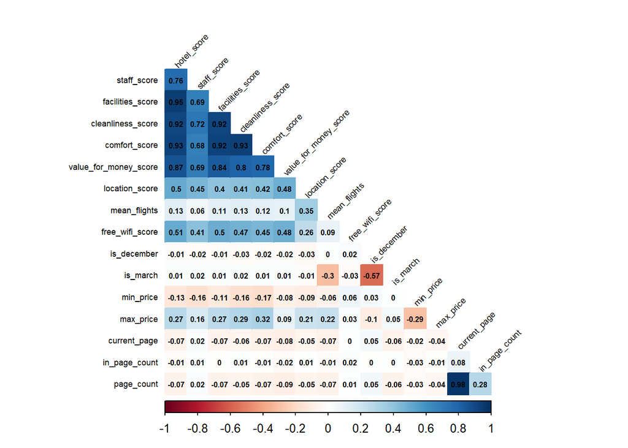

```r
# Creamos una matriz de correlación del dataset
cor_mat <- cor(mattmp, method = "spearman")
plot.new()
plot.window(xlim=c(-2,2), ylim=c(5,10))
corrplot(cor_mat, method="color", type = "lower", tl.col = "black", tl.srt = 45, diag = FALSE, tl.cex = 0.55, addCoef.col = 'black', number.cex = 0.5)
```

```r
mattmp <- booking_numeric %>%
  dplyr::select(c("balcony", "swimming_pool", "pet_friendly", "kitchen", "city_view", "is_apartment", "non_smoking_rooms", "hotel_score",
           "private_bathroom", "elevator", "heating", "safe", "air_conditioning", "free_wifi", "max_price", "min_price", "current_page", "in_page_count", "page_count"))

sapply(mattmp, function(y) sum(is.na(y)))
```

```
##           balcony     swimming_pool      pet_friendly           kitchen
##                 0                 0                 0                 0
##         city_view      is_apartment non_smoking_rooms       hotel_score
##                 0                 0                 0                 0
##  private_bathroom          elevator           heating              safe
##                 0                 0                 0                 0
##  air_conditioning         free_wifi         max_price         min_price
##                 0                 0                 0                 0
##      current_page     in_page_count        page_count
##                 0                 0                 0
```

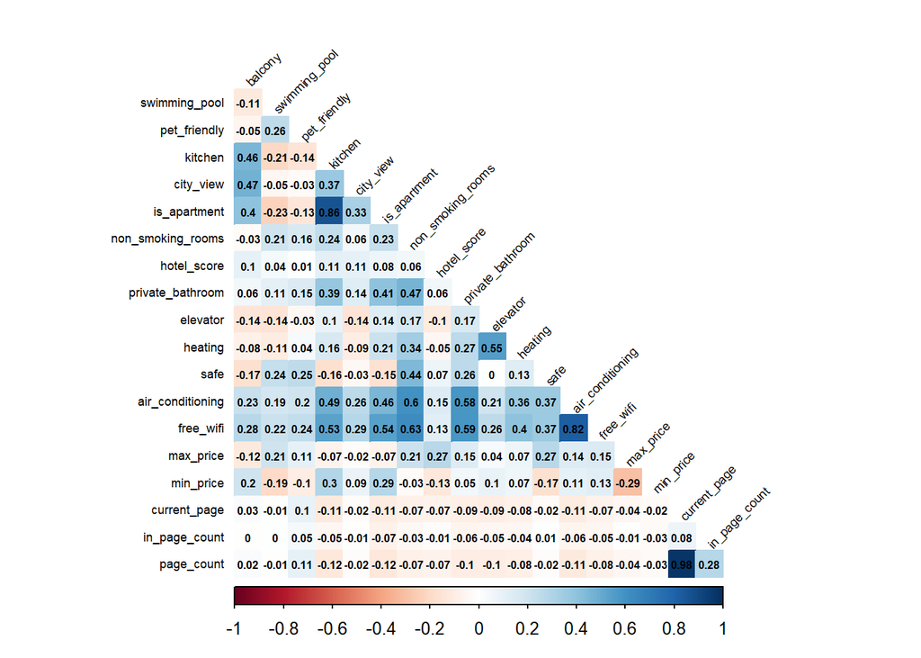

```r
# Creamos una matriz de correlación del dataset
cor_mat <- cor(mattmp, method = "spearman")
plot.new()
plot.window(xlim=c(-2,2), ylim=c(5,10))
corrplot(cor_mat, method="color", type = "lower", tl.col = "black", tl.srt = 45, diag = FALSE, tl.cex = 0.55, addCoef.col = 'black', number.cex = 0.5)
```

```r
# Filtramos para obtener cuales son las variables más correlacionadas con nuestra variable objetivo, current_page
cor_mat <- cor(booking_numeric, method = "spearman")
cor_mat_df <- as.data.frame(cor_mat)
cor_mat_df %>%
  filter(abs(page_count) > 0.065) %>%
  filter(page_count < 0.95) %>%
  arrange(page_count) %>%
  dplyr::select(page_count)
```

```
##                        page_count
## kitchen               -0.12023093
## is_apartment          -0.12015885
## adults                -0.11580745
## air_conditioning      -0.11400432
## elevator              -0.09860877
## private_bathroom      -0.09661382
## num_rooms             -0.08662662
## value_for_money_score -0.08574257
## heating               -0.08399204
## free_wifi             -0.07529422
## non_smoking_rooms     -0.07424905
## mean_flights          -0.06952514
## comfort_score         -0.06936356
## hotel_score           -0.06765554
## facilities_score      -0.06508687
## longitude              0.07601044
## pet_friendly           0.10535168
## in_page_count          0.28025901
```

```r
# Filtramos para obtener cuales son las variables más correlacionadas con nuestra variable objetivo, page_count
cor_mat <- cor(booking_numeric, method = "spearman")
cor_mat_df <- as.data.frame(cor_mat)
cor_mat_df %>%
  filter(abs(max_price) > 0.1) %>%
  filter(max_price < 0.95) %>%
  arrange(max_price) %>%
  dplyr::select(max_price)
```

```
##                     max_price
## min_price          -0.2933215
## postal_code        -0.1244939
## balcony            -0.1185999
## pet_friendly        0.1073362
## latitude            0.1271236
## air_conditioning    0.1408840
## private_bathroom    0.1452074
## free_wifi           0.1523803
## staff_score         0.1640168
## swimming_pool       0.2055779
## non_smoking_rooms   0.2110602
## location_score      0.2116932
## mean_flights        0.2224695
## length_description  0.2287604
## facilities_score    0.2667483
## hotel_score         0.2700575
## safe                0.2719657
## cleanliness_score   0.2919506
## comfort_score       0.3206842
```

A modo ilustrativo podemos graficar un scatter plot para visualizar la variable que más parece estar relacionada con el precio, el comfort_score.

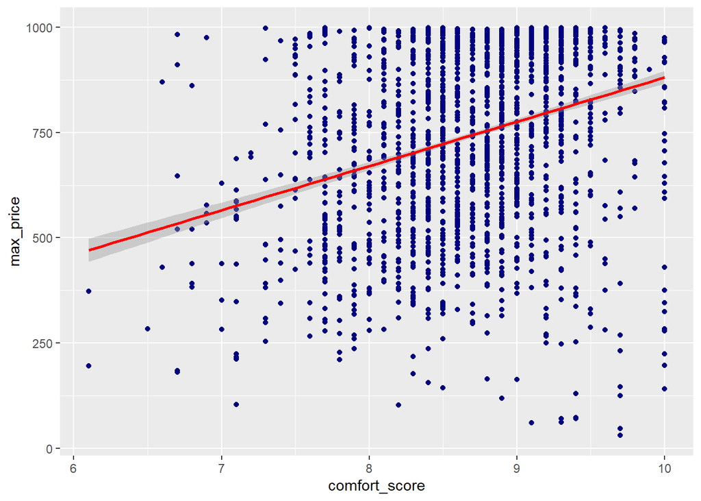

```r
ggplot(booking, aes(comfort_score, max_price)) +
  geom_point(color = "navy") +
  geom_smooth(method = "lm", color = "red")
```

#### 4.2 Comprobación de la normalidad y homogeneidad de la varianza

Para comprobar si los valores de las variables de nuestro dataset se distribuyen o se aproximan a una población distribuida normalmente haremos un análisis visual, con QQ-Plots e Histogramas, y un análisis mediante el test Shapiro-Wilk. Concretamente, solo comprobaremos la normalidad para las variables seleccionadas en el apartado anterior.

```r
# Seleccionamos las variables a analizar
norm_cols <- c("value_for_money_score", "comfort_score", "hotel_score", "staff_score", "cleanliness_score", "location_score", "facilities_score", "length_description", "min_price", "max_price", "page_count")

booking_norm <- booking_numeric %>%
  dplyr::select(norm_cols)
```

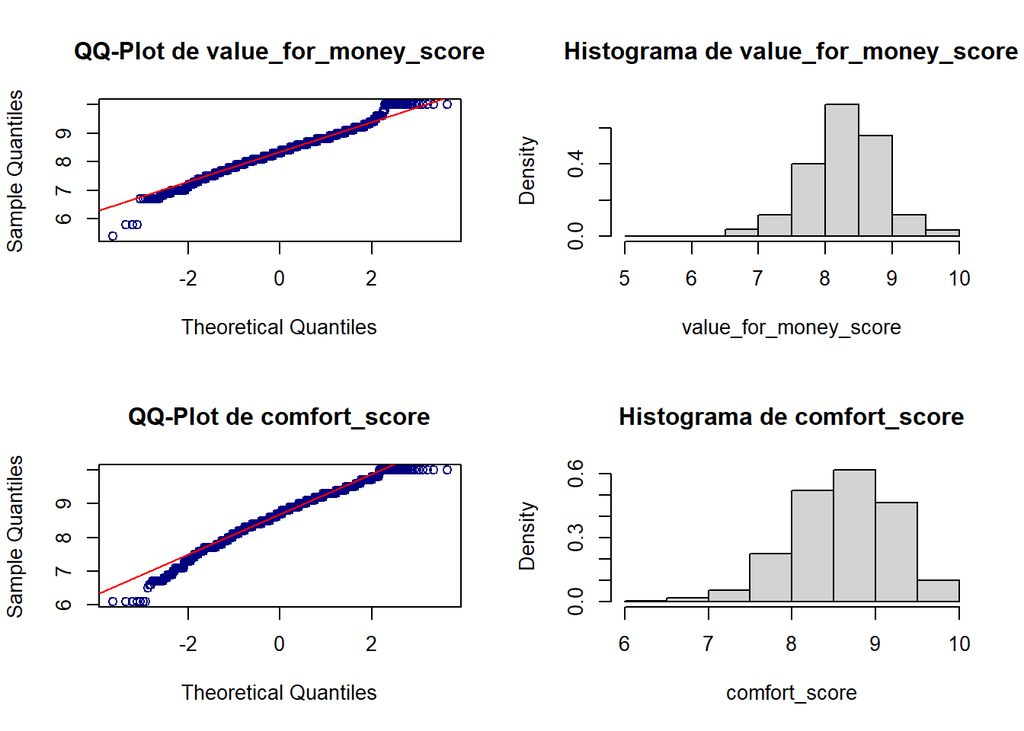

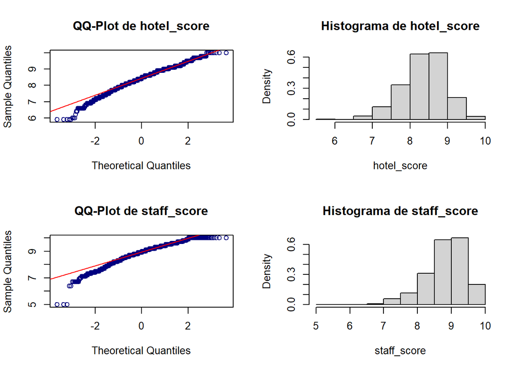

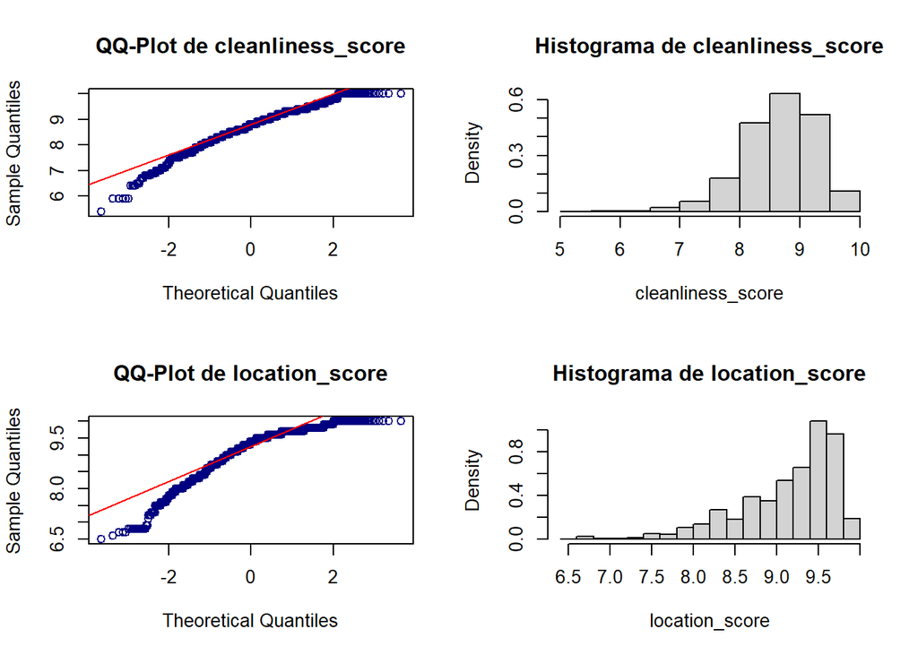

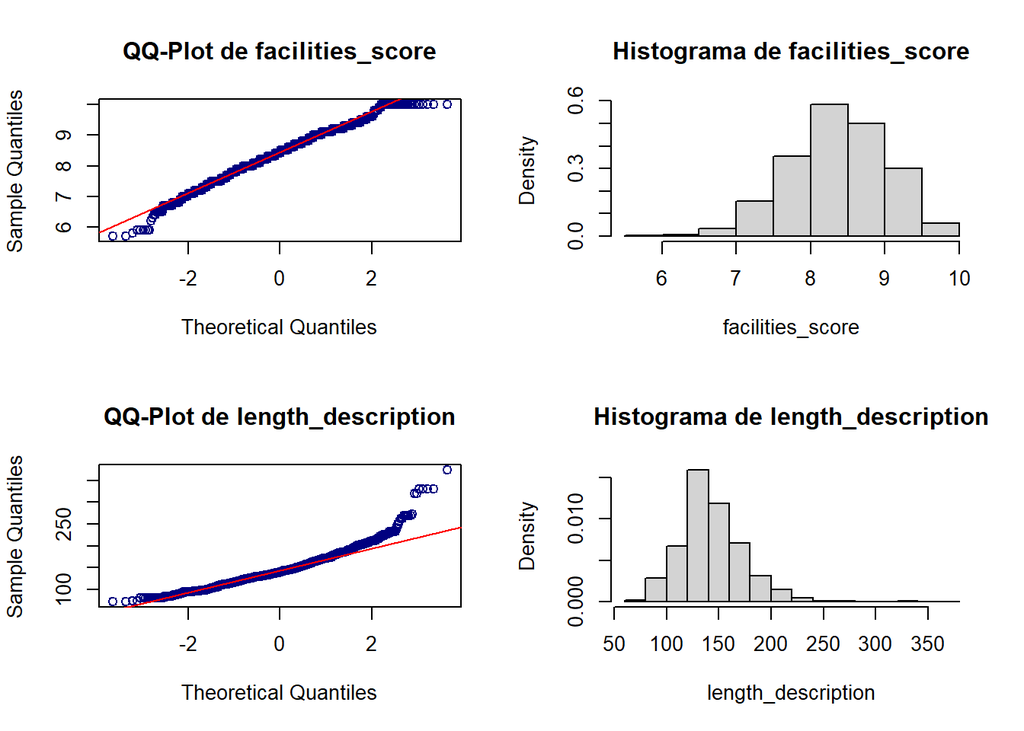

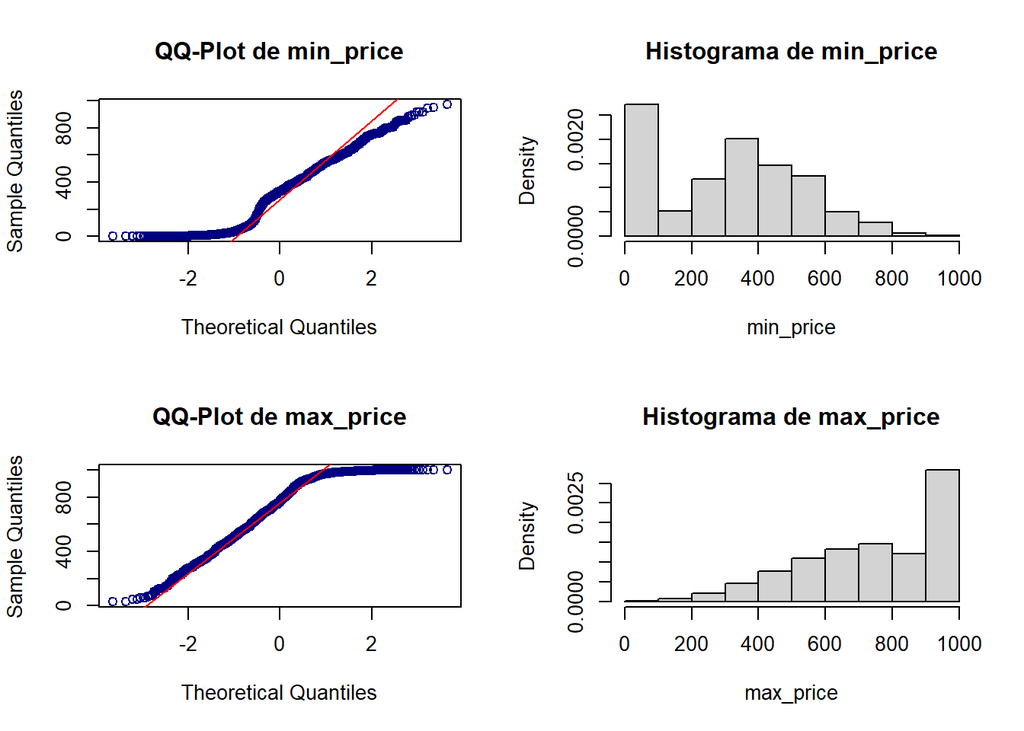

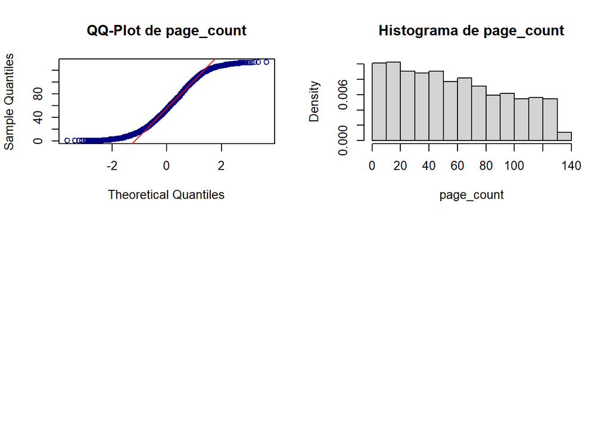

```r
# Ploteamos los qq-plots y los histogramas
par(mfrow=c(2,2))
for(i in 1:ncol(booking_norm)){
  qqnorm(booking_norm[,i], main = paste("QQ-Plot de",colnames(booking_norm)[i]), col = "navy")
  qqline(booking_norm[,i], col = "red")
  hist(booking_norm[,i], main = paste("Histograma de", colnames(booking_norm)[i]), xlab=colnames(booking_norm)[i], freq = FALSE)
}
```

Los QQ-plots y los histogramas nos muestran una distribuciones con una evidente asimetría negativa en la mayoría de los casos (excepto variables como length_description que muestran una asimetría más bien positiva, aunque podría ser influencia de un dato extremo que no ha sido considerado outlier), así como un evidente problema con las colas, pues en la mayoría de los casos los puntos se alejan de la línea roja, la cual corresponde a la hipotética distribución normal. Por tanto, a priori podríamos rechazar la hipótesis de normalidad de las variables. Es más, tras ejecutar el test Shapiro-Wilk confirmamos de forma más fiable nuestras primeras conclusiones, pues todos los p-valores muestran valores muy inferiores a 0.05, rechazando en todos los casos la hipótesis nula sobre la normalidad de los datos.

```r
# Calculamos el test de Shapiro-Wilk para cada variable y sacamos su pvalor
pvalues <- t(data.frame(lapply(booking_norm, function(y) format(shapiro.test(y)$p.value, digits = 3))))

kable(pvalues, col.names = c("p-value"))
```

|  | p-value |
| --- | --- |
| value_for_money_score | 1.23e-18 |
| comfort_score | 9.62e-22 |
| hotel_score | 8.63e-21 |
| staff_score | 8.08e-32 |
| cleanliness_score | 2.19e-26 |
| location_score | 8.67e-46 |
| facilities_score | 1.54e-15 |
| length_description | 6.06e-33 |
| min_price | 6.87e-35 |
| max_price | 3.71e-40 |
| page_count | 2.73e-34 |

A fin de aproximar más los datos a una distribución normal, se propone hacer una transformación de box-cox y comprobar si los datos efectivamente se aproximan más a una normal. Tras llevar a cabo este proceso, si bien los histogramas muestran en algunos casos una distribución “visualmente más normales” y los QQ-plots parecen mostrar que la transformación ha aliviado ligeramente el problema con las colas, los resultados de la transformación no han sido suficientes como para poder considerar que los datos se distribuyen como una normal. No obstante, no debemos preocuparnos demasiado por este problema, pues tenemos suficientes registros como para poder apoyarnos en el Teorema del Límite Central. Por ejemplo, el t-test asume que las medias de las diferentes muestras se distribuyen normalmente (siendo una muestra de más de 30 registros suficiente, como rule of thumb, para que el t-test sea válido aunque los datos no se distribuyan normalmente).

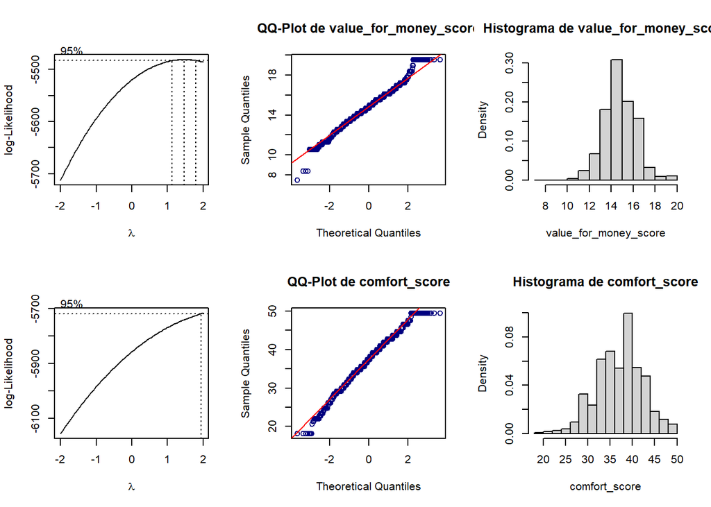

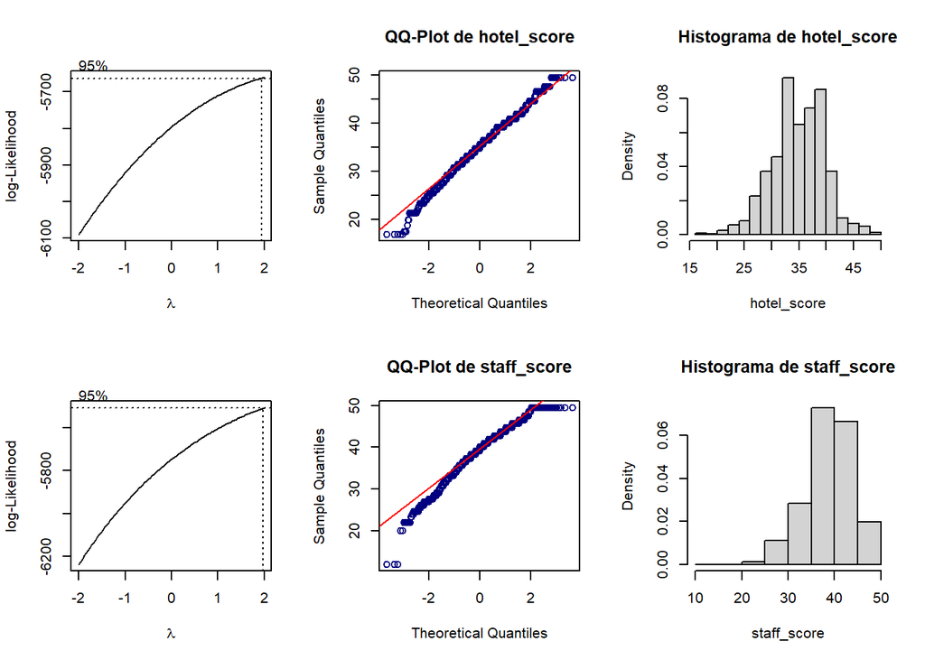

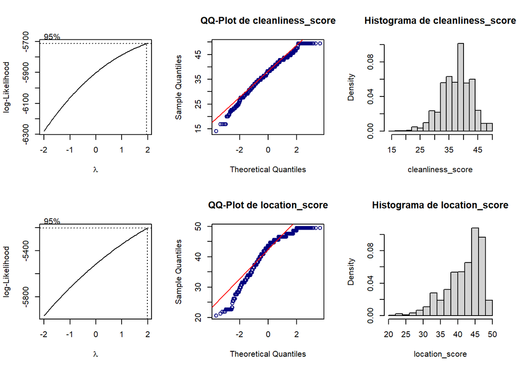

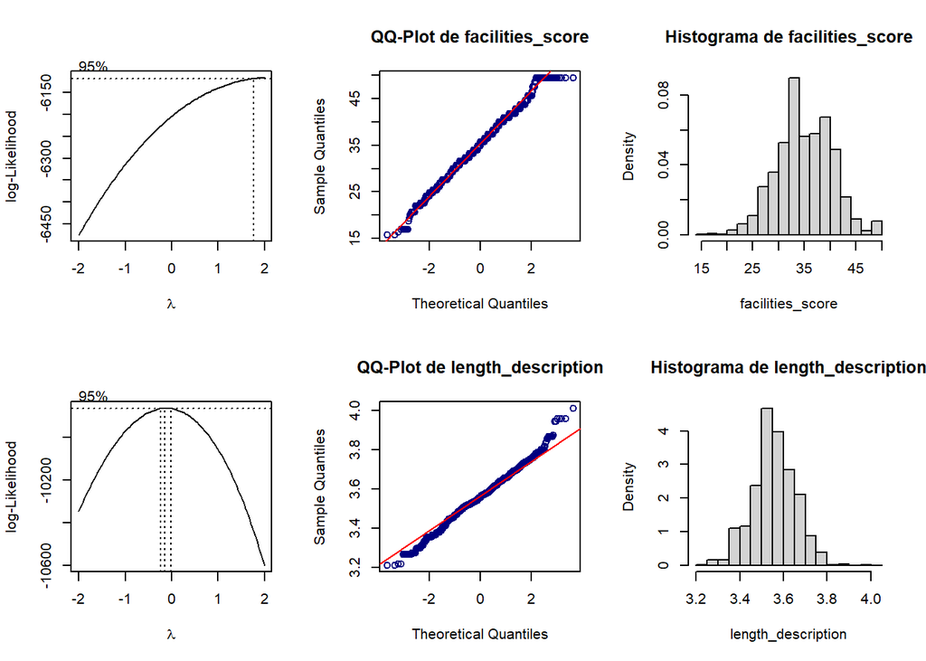

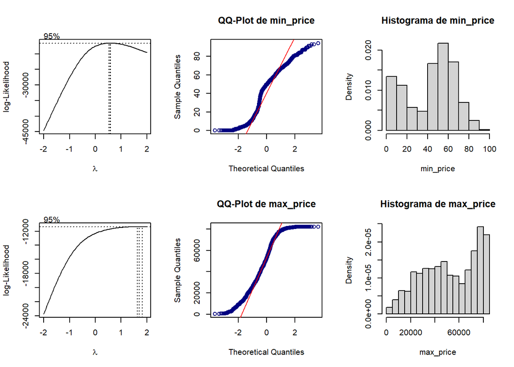

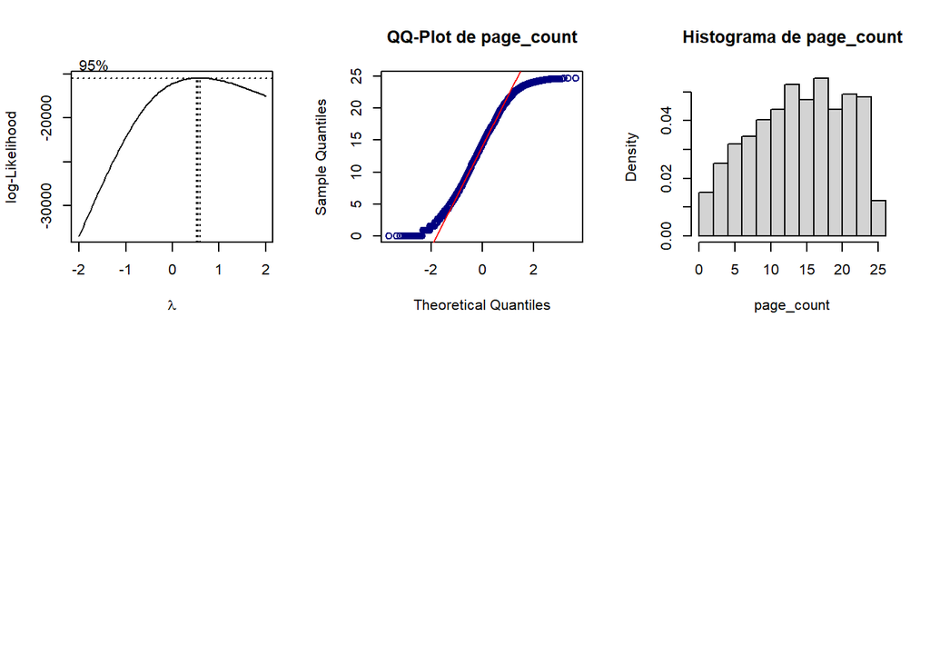

```r
# Ploteamos los qq-plots y los histogramas
par(mfrow=c(2,3))
for(i in 1:ncol(booking_norm)){
  b <- boxcox(lm(booking_norm[,i] ~ 1))
  lambda <- b$x[which.max(b$y)]
  qqnorm((booking_norm[,i]^lambda - 1)/lambda, main = paste("QQ-Plot de",colnames(booking_norm)[i]), col = "navy")
  qqline((booking_norm[,i]^lambda - 1)/lambda, col = "red")
  hist((booking_norm[,i]^lambda - 1)/lambda, main = paste("Histograma de", colnames(booking_norm)[i]), xlab=colnames(booking_norm)[i], freq = FALSE)
}
```

Seguidamente, analizaremos la homocedasticidad mediante scatterplots y varios test de homocedasticidad, o de homogeneidad de varianzas. En este caso, no podemos utilizar el test de Barlett ya que es muy sensible ante datos no normales y, como acabamos de presentar, los datos analizados no se aproximan en ningún caso a una normal. Por tanto, en este caso haremos uso del test de Fligner-Killeen.

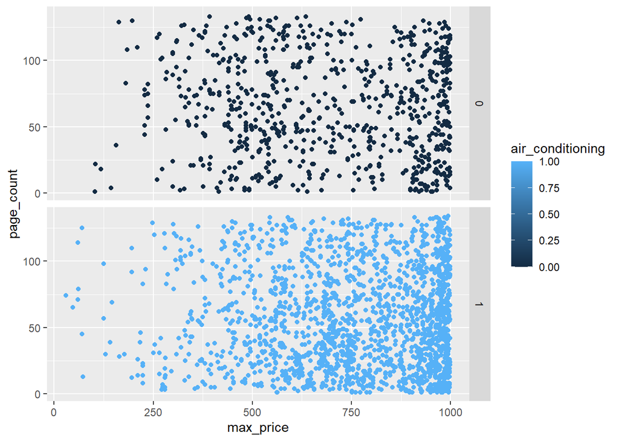

```r
# Generamos el scatter para compromar la homocedasticidad de page_count cuando dividimos por air_conditioning.
ggplot(booking, aes(x = max_price, y = page_count, color = air_conditioning)) +
  geom_point() +
  facet_grid(air_conditioning~.)
```

Como todos los test de homogeneidad de varianzas, nos basamos en las siguientes hipótesis:

$$H_0: \sigma_{i}^2 = \dots =
\sigma_{j}^2$$
$$H_0: \sigma_{i}^2
\neq \sigma_{j}^2 \textrm{ para al menos un conjunto
(i,j)}$$